# Shiau Shian Liu_Analysis of Solar Adoption Patterns in the Melbourne Residential Market

## **Executive Summary:**

This analysis investigates residential solar adoption patterns across 221 Melbourne postcodes to help ARENA identify priority areas for solar promotion. Three data sources are integrated: Melbourne housing transaction records, solar installation data, and 2021 ABS Census dwelling tenure data.

**Method:** K-Means clustering groups postcodes into three distinct area types based on seven features (property price, dwelling size, distance from CBD, transaction volume, property count, solar output, and ownership rate). OLS regression quantifies how distance, dwelling size, and ownership rate each relate to solar adoption.

**Key Findings:**

- Three area types emerge: Outer Fringe (98 postcodes, outer areas, high ownership, moderate solar), Urban Core (104 postcodes, inner-city, low solar), and Suburban High-Adoption Hub (19 postcodes, large-scale communities, highest solar).
- Dwelling size is the strongest predictor of solar adoption (p < 0.001), followed by distance from CBD (p = 0.019). Both confirm that areas with larger, separate houses further from the CBD have higher solar output (H1 and H2 Supported).
- Ownership rate shows a significant but negative relationship with total solar output (p < 0.001, H3 Not Supported), indicating that community scale drives total adoption more than ownership proportion alone.
- 20 priority postcodes are identified where actual solar output is 63–96% below model predictions, predominantly in Outer Fringe areas with favourable housing conditions but very low adoption.

**Recommendations:** ARENA should prioritise outer suburban and semi-rural postcodes where large dwellings and high ownership rates create ideal conditions but adoption remains extremely low. Dwelling size and distance from the CBD should be adopted as key targeting criteria. Future analysis should incorporate per-household adoption rates to better isolate the effect of ownership on individual solar uptake.

## **Business Theme:**

Analysis of Solar Adoption Patterns in the Melbourne Residential Market

## **Objective:**

To identify residential solar adoption patterns across Melbourne suburbs using clustering analysis, and to examine how area characteristics — including distance, dwelling type, and home ownership — relate to adoption, in order to help ARENA identify priority areas for solar promotion.

## **Business Question:**

ARENA aims to increase residential solar adoption across Melbourne. To target its efforts effectively, this analysis investigates:

#### 1. Which area characteristics are associated with residential solar adoption across Melbourne postcodes?

#### 2. Which postcodes show suitable conditions for solar but currently have low adoption, representing priority for ARENA?

## **Phase 1: Business & Data Understanding & Specific requirements**

This phase defines the business context: ARENA's objective to increase residential solar adoption across Melbourne. The two business questions, three hypotheses, and assessment requirements are established, and the three data sources (Clean Energy Regulator (CER) solar data, Kaggle housing data, Australian Bureau of Statistics (ABS) Census data) are identified and explored for quality and structure.

### **1-1 Specific requirements**

- Discussion of at least two clustering techniques
- Application of at least one clustering technique
- Effectiveness of clustering and interpretation of the clusters
- Use of significance testing on at least one occasion
- Demonstrate and highlight usage of feature extraction
- Appropriate visualization of the results (geo-spatial visualization is recommended)

### **1-2 Business Understanding**

- Understand ARENA’s objective
- Explore Melbourne residential and solar adoption patterns
- Define clustering goals
- Inform decisions about future solar energy projects and policies

### **1-3 Business Hypotheses**

- **Hypothesis 1 (H1):**

Postcode further from the CBD have higher solar adoption, as outer suburbs contain more separate houses with suitable roof space.  
*Tested using: Avg_Distance vs Total_Output_kW*

- **Hypothesis 2 (H2):**

Postcodes with larger dwellings(more rooms)have higher solar adoption.  
*Tested using: Avg_Rooms vs Total_Output_kW*

- **Hypothesis 3 (H3):**

Postcodes with a higher home-ownership rate have higher solar adoption, as owner-occupiers are more likely to invest in solar than renters.  
*Tested using: Ownership_Rate (from Census G37) vs Total_Output_kW*

### **1-4 Data Understanding**

- Explore housing and solar datasets
- Identify important variables
- Evaluate data quality and missing values
- Determine postcode as the join key
- Focus on Melbourne regional data
- Incorporate 2021 ABS Census data(income and housing tenure) at the Postal Area(POA)level

### **1-5 Understanding Map**

| Dataset | Unit of Analysis | Key Variables | Potential Usage |
| --- | --- | --- | --- |
| MELBOURNE_HOUSE_PRICES_LESS | One property transaction | Price, Rooms, Distance, Type, Postcode, CouncilArea | Housing characteristics |
| Melbourne_housing_FULL | One property transaction | Landsize, YearBuilt, Latitude, Longitude | Secondary reference dataset |
| Solar Capacity | Solar capacity by postcode and year | Postcode, Year, Capacity | Solar adoption level |
| Solar Installations | Solar installations by postcode and year | Postcode, Year, Installations | Solar adoption activity |
| Australian Postcodes | Australian postcode reference | Postcode, Locality, State | Melbourne postcode filtering |
| Census G37 (2021 ABS) | One postcode (POA) | Owner-occupied / rented counts, dwelling structure | Home ownership and housing profile analysis |

### **1-6 Data Relationships**

| Dataset | Join Key | Relationship |
| --- | --- | --- |
| MELBOURNE_HOUSE_PRICES_LESS | Postcode | Main housing dataset |
| Australian Postcodes | Postcode | Used to identify Melbourne postcodes |
| Solar Capacity | Postcode | Joined to housing data |
| Solar Installations | Postcode | Joined to housing data |
| Census G37 (2021 ABS) | Postcode (POA) | Integrated with housing and solar datasets |

### **1-7 Tools & Methods**

**Tools:**

- Python 3 (Jupyter Notebook via VS Code)
- Libraries: pandas, numpy, scikit-learn, matplotlib, seaborn, statsmodels, folium, scipy

**Analytical Methods:**

- K-Means clustering (postcode segmentation into area types)
- Hierarchical clustering and DBSCAN (discussed as alternatives in Section 4-1)
- Elbow method and Silhouette score (optimal cluster selection)
- Ordinary Least Squares (OLS) multiple linear regression (quantifying factor–adoption relationships)
- Pearson correlation analysis (feature redundancy check)
- Residual analysis (identifying solar gap postcodes)

**Data Sources:**

- Clean Energy Regulator (CER): Solar installation and output data by postcode
- Kaggle Melbourne Housing Dataset: Property transactions with price, rooms, distance, and coordinates
- ABS 2021 Census (Table G37): Dwelling tenure by Postal Area, used to derive home-ownership rates

**Visualisation:**

- Folium interactive geo-spatial maps (cluster distribution and priority postcodes)
- Seaborn heatmaps (feature correlation)
- Matplotlib bar charts, scatter plots, histograms, and box plots
- StandardScaler normalised profile charts (cluster comparison)

## **Phase 2: Data Preparation**

This phase cleans and integrates the three data sources into a single postcode-level dataset. Key tasks include filtering for Melbourne postcodes, handling missing values, aggregating housing transactions to the postcode level, merging solar installation data, and deriving the home-ownership rate from Census data. The output is a clean dataset of 221 postcodes with all features ready for analysis.

### **2-1 Initial Data Inspection & renaming**

Import libraries and inspect file solar_capacity(df_cap)

```python
import pandas as pd
df_cap= pd.read_csv(r"C:\Users\falli\OneDrive\Desktop\Tafe\Assessment 4 PROJECT Clustering and machine learning\data\sgu-solar-capacity-2011-to-present.csv")
df_cap.head()
# df_cap.shape
# df_cap.columns
# df_cap.dtypes
# df_cap.isnull().sum()
```

|  | Small Unit Installation Postcode | Jan 2011 - SGU Rated Output In kW | Feb 2011 - SGU Rated Output In kW | Mar 2011 - SGU Rated Output In kW | Apr 2011 - SGU Rated Output In kW | May 2011 - SGU Rated Output In kW | Jun 2011 - SGU Rated Output In kW | Jul 2011 - SGU Rated Output In kW | Aug 2011 - SGU Rated Output In kW | Sep 2011 - SGU Rated Output In kW | ... | Jul 2023 - SGU Rated Output In kW | Aug 2023 - SGU Rated Output In kW | Sep 2023 - SGU Rated Output In kW | Oct 2023 - SGU Rated Output In kW | Nov 2023 - SGU Rated Output In kW | Dec 2023 - SGU Rated Output In kW | Jan 2024 - SGU Rated Output In kW | Feb 2024 - SGU Rated Output In kW | Mar 2024 - SGU Rated Output In kW | Apr 2024 - SGU Rated Output In kW |
| --- | --- | --- | --- | --- | --- | --- | --- | --- | --- | --- | --- | --- | --- | --- | --- | --- | --- | --- | --- | --- | --- |
| 0 | 0 | 0.0 | 0.0 | 0.0 | 0.0 | 0.00 | 0.0 | 0.00 | 0.0 | 0.0 | ... | 0.00 | 0.00 | 0.0 | 0.0 | 0.00 | 0.0 | 0.0 | 0.0 | 0.0 | 0.0 |
| 1 | 200 | 0.0 | 0.0 | 0.0 | 0.0 | 0.00 | 0.0 | 0.00 | 0.0 | 0.0 | ... | 0.00 | 0.00 | 0.0 | 0.0 | 0.00 | 0.0 | 0.0 | 0.0 | 0.0 | 0.0 |
| 2 | 800 | 0.0 | 0.0 | 0.0 | 0.0 | 2.22 | 0.0 | 3.04 | 0.0 | 0.0 | ... | 39.96 | 55.15 | 0.0 | 0.0 | 62.25 | 0.0 | 0.0 | 0.0 | 0.0 | 0.0 |
| 3 | 801 | 0.0 | 0.0 | 0.0 | 0.0 | 2.02 | 0.0 | 0.00 | 0.0 | 0.0 | ... | 0.00 | 0.00 | 0.0 | 0.0 | 0.00 | 0.0 | 0.0 | 0.0 | 0.0 | 0.0 |
| 4 | 803 | 0.0 | 0.0 | 0.0 | 0.0 | 0.00 | 0.0 | 0.00 | 0.0 | 0.0 | ... | 0.00 | 0.00 | 0.0 | 0.0 | 0.00 | 0.0 | 0.0 | 0.0 | 0.0 | 0.0 |

5 rows × 161 columns

Import libraries and inspect file solar_installation(df_install)

```python
df_install= pd.read_csv(r"C:\Users\falli\OneDrive\Desktop\Tafe\Assessment 4 PROJECT Clustering and machine learning\data\sgu-solar-installations-2011-to-present.csv")
df_install.head()
# df_install.shape
# df_install.columns
# df_install.dtypes
# df_install.isnull().sum()
```

|  | Small Unit Installation Postcode | Jan 2011 - Installations Quantity | Feb 2011 - Installations Quantity | Mar 2011 - Installations Quantity | Apr 2011 - Installations Quantity | May 2011 - Installations Quantity | Jun 2011 - Installations Quantity | Jul 2011 - Installations Quantity | Aug 2011 - Installations Quantity | Sep 2011 - Installations Quantity | ... | Jul 2023 - Installations Quantity | Aug 2023 - Installations Quantity | Sep 2023 - Installations Quantity | Oct 2023 - Installations Quantity | Nov 2023 - Installations Quantity | Dec 2023 - Installations Quantity | Jan 2024 - Installations Quantity | Feb 2024 - Installations Quantity | Mar 2024 - Installations Quantity | Apr 2024 - Installations Quantity |
| --- | --- | --- | --- | --- | --- | --- | --- | --- | --- | --- | --- | --- | --- | --- | --- | --- | --- | --- | --- | --- | --- |
| 0 | 0 | 0 | 0 | 0 | 0 | 0 | 0 | 0 | 0 | 0 | ... | 0 | 0 | 0 | 0 | 0 | 0 | 0 | 0 | 0 | 0 |
| 1 | 200 | 0 | 0 | 0 | 0 | 0 | 0 | 0 | 0 | 0 | ... | 0 | 0 | 0 | 0 | 0 | 0 | 0 | 0 | 0 | 0 |
| 2 | 800 | 0 | 0 | 0 | 0 | 1 | 0 | 1 | 0 | 0 | ... | 1 | 2 | 0 | 0 | 1 | 0 | 0 | 0 | 0 | 0 |
| 3 | 801 | 0 | 0 | 0 | 0 | 1 | 0 | 0 | 0 | 0 | ... | 0 | 0 | 0 | 0 | 0 | 0 | 0 | 0 | 0 | 0 |
| 4 | 803 | 0 | 0 | 0 | 0 | 0 | 0 | 0 | 0 | 0 | ... | 0 | 0 | 0 | 0 | 0 | 0 | 0 | 0 | 0 | 0 |

5 rows × 161 columns

Load 3 files: Australian postcode (df_postcode), Melbourne house less(df_house_less), Melbourne house full(df_house_full)

```python
df_postcode= pd.read_csv(r"C:\Users\falli\OneDrive\Desktop\Tafe\Assessment 4 PROJECT Clustering and machine learning\data\australian_postcodes.csv")
df_postcode.head()
df_house_less= pd.read_csv(r"C:\Users\falli\OneDrive\Desktop\Tafe\Assessment 4 PROJECT Clustering and machine learning\data\MELBOURNE_HOUSE_PRICES_LESS.csv")
df_house_less.head()
df_house_full= pd.read_csv(r"C:\Users\falli\OneDrive\Desktop\Tafe\Assessment 4 PROJECT Clustering and machine learning\data\Melbourne_housing_FULL.csv")
df_house_full.head()
```

|  | Suburb | Address | Rooms | Type | Price | Method | SellerG | Date | Distance | Postcode | ... | Bathroom | Car | Landsize | BuildingArea | YearBuilt | CouncilArea | Lattitude | Longtitude | Regionname | Propertycount |
| --- | --- | --- | --- | --- | --- | --- | --- | --- | --- | --- | --- | --- | --- | --- | --- | --- | --- | --- | --- | --- | --- |
| 0 | Abbotsford | 68 Studley St | 2 | h | NaN | SS | Jellis | 3/09/2016 | 2.5 | 3067.0 | ... | 1.0 | 1.0 | 126.0 | NaN | NaN | Yarra City Council | -37.8014 | 144.9958 | Northern Metropolitan | 4019.0 |
| 1 | Abbotsford | 85 Turner St | 2 | h | 1480000.0 | S | Biggin | 3/12/2016 | 2.5 | 3067.0 | ... | 1.0 | 1.0 | 202.0 | NaN | NaN | Yarra City Council | -37.7996 | 144.9984 | Northern Metropolitan | 4019.0 |
| 2 | Abbotsford | 25 Bloomburg St | 2 | h | 1035000.0 | S | Biggin | 4/02/2016 | 2.5 | 3067.0 | ... | 1.0 | 0.0 | 156.0 | 79.0 | 1900.0 | Yarra City Council | -37.8079 | 144.9934 | Northern Metropolitan | 4019.0 |
| 3 | Abbotsford | 18/659 Victoria St | 3 | u | NaN | VB | Rounds | 4/02/2016 | 2.5 | 3067.0 | ... | 2.0 | 1.0 | 0.0 | NaN | NaN | Yarra City Council | -37.8114 | 145.0116 | Northern Metropolitan | 4019.0 |
| 4 | Abbotsford | 5 Charles St | 3 | h | 1465000.0 | SP | Biggin | 4/03/2017 | 2.5 | 3067.0 | ... | 2.0 | 0.0 | 134.0 | 150.0 | 1900.0 | Yarra City Council | -37.8093 | 144.9944 | Northern Metropolitan | 4019.0 |

5 rows × 21 columns

### **2-2 Solar Capacity Reshaping (df_cap)**

- **Column Standardization:** Manually renamed the primary geographical identifier to `Postcode` to establish a unified join key across all datasets.
- **Data Transformation (Melt):** Reshaped `df_cap` from a wide (horizontal) format into a long (vertical) format, isolating `Postcode`, `Month_year_cap`, and `Output_kW` for subsequent aggregation.

```python
df_cap= df_cap.rename(columns= {
'Small Unit Installation Postcode':'Postcode',
})

Month_year_cap= {}
for col in df_cap.columns:
    if '-' in col:
        new_name= col.split('-')[0].strip()
        Month_year_cap[col]= new_name
df_cap= df_cap.rename(columns=Month_year_cap)

df_cap.head()
df_cap_long= df_cap.melt(id_vars= 'Postcode',
var_name= 'Month_year_cap',
value_name= 'Output_kW')
df_cap_long.head(-5)
```

|  | Postcode | Month_year_cap | Output_kW |
| --- | --- | --- | --- |
| 0 | 0 | Jan 2011 | 0.00 |
| 1 | 200 | Jan 2011 | 0.00 |
| 2 | 800 | Jan 2011 | 0.00 |
| 3 | 801 | Jan 2011 | 0.00 |
| 4 | 803 | Jan 2011 | 0.00 |
| ... | ... | ... | ... |
| 449430 | 7331 | Apr 2024 | 6.64 |
| 449431 | 7466 | Apr 2024 | 0.00 |
| 449432 | 7467 | Apr 2024 | 0.00 |
| 449433 | 7468 | Apr 2024 | 0.00 |
| 449434 | 7469 | Apr 2024 | 0.00 |

449435 rows × 3 columns

### **2-3 Solar Installations Transformation**

- **Column Standardization:** Manually renamed the primary geographical identifier to `Postcode` to establish a unified join key across all datasets.
- **Data Transformation (Melt):** Reshaped `df_install` from a wide format into a long format, isolating `Postcode`, `Month_year_inst`, and `Inst_Qty` for subsequent aggregation.

```python
df_install= df_install.rename(columns= {
'Small Unit Installation Postcode':'Postcode',
})

Month_year_install= {}
for col in df_install.columns:
    if '-' in col:
        new_name= col.split('-')[0].strip()
        Month_year_install[col]= new_name
df_install= df_install.rename(columns=Month_year_install)

df_install.head()
df_install_long= df_install.melt(id_vars= 'Postcode',
                                 var_name='Month_year_inst',
                                 value_name= 'Inst_Qty'
)

df_install_long.head(-5)
```

|  | Postcode | Month_year_inst | Inst_Qty |
| --- | --- | --- | --- |
| 0 | 0 | Jan 2011 | 0 |
| 1 | 200 | Jan 2011 | 0 |
| 2 | 800 | Jan 2011 | 0 |
| 3 | 801 | Jan 2011 | 0 |
| 4 | 803 | Jan 2011 | 0 |
| ... | ... | ... | ... |
| 449430 | 7331 | Apr 2024 | 1 |
| 449431 | 7466 | Apr 2024 | 0 |
| 449432 | 7467 | Apr 2024 | 0 |
| 449433 | 7468 | Apr 2024 | 0 |
| 449434 | 7469 | Apr 2024 | 0 |

449435 rows × 3 columns

### **2-4 Solar Dataset Merge (cap + install)**

Table merging the two columns 'df_cap_long' and 'de_install_long'**  
Using a Composite Key (Postcode and Month_year).'

```python
df_solar= df_cap_long.merge(
    df_install_long,
    left_on=['Postcode','Month_year_cap'],
    right_on=[ 'Postcode','Month_year_inst'],
    how= 'inner'
)

# df_solar.head()
df_solar= df_solar.drop(columns= ['Month_year_inst'])
df_solar= df_solar.rename(columns= {'Month_year_cap':'Month_year'})

df_solar.head()
```

|  | Postcode | Month_year | Output_kW | Inst_Qty |
| --- | --- | --- | --- | --- |
| 0 | 0 | Jan 2011 | 0.0 | 0 |
| 1 | 200 | Jan 2011 | 0.0 | 0 |
| 2 | 800 | Jan 2011 | 0.0 | 0 |
| 3 | 801 | Jan 2011 | 0.0 | 0 |
| 4 | 803 | Jan 2011 | 0.0 | 0 |

### **2-5 Melbourne Postcode Filtering**

In file 'df_postcode' there has column 'State', VIC= Victoria = Melbourne area

```python
# Inspect df_postcode
df_postcode.shape
df_postcode.isnull().sum()
df_postcode.dtypes
df_postcode.info()
df_postcode.shape
df_postcode.columns
# df_postcode.describe()
```

```
<class 'pandas.core.frame.DataFrame'>
RangeIndex: 18545 entries, 0 to 18544
Data columns (total 41 columns):
 #   Column            Non-Null Count  Dtype
---  ------            --------------  -----
 0   id                18545 non-null  int64
 1   postcode          18545 non-null  int64
 2   locality          18545 non-null  object
 3   state             18545 non-null  object
 4   long              18545 non-null  float64
 5   lat               18545 non-null  float64
 6   dc                17947 non-null  object
 7   type              16911 non-null  object
 8   status            18519 non-null  object
 9   sa3               18384 non-null  float64
```

[output cut: 33 more lines]

```
Index(['id', 'postcode', 'locality', 'state', 'long', 'lat', 'dc', 'type',
       'status', 'sa3', 'sa3name', 'sa4', 'sa4name', 'region', 'Lat_precise',
       'Long_precise', 'SA1_CODE_2021', 'SA1_NAME_2021', 'SA2_CODE_2021',
       'SA2_NAME_2021', 'SA3_CODE_2021', 'SA3_NAME_2021', 'SA4_CODE_2021',
       'SA4_NAME_2021', 'RA_2011', 'RA_2016', 'RA_2021', 'RA_2021_NAME',
       'MMM_2015', 'MMM_2019', 'ced', 'altitude', 'chargezone', 'phn_code',
       'phn_name', 'lgaregion', 'lgacode', 'electorate', 'electoraterating',
       'sed_code', 'sed_name'],
      dtype='object')
```

```python
# From df_postcodes find all 'state' == 'VIC' and only select 'postcodes' column.
# Using .unique() method to exclude the duplicates then save is the list naming `vic_postcodes`
vic_postcodes= df_postcode[df_postcode['state']== 'VIC']['postcode'].unique()

df_solar_vic= df_solar[df_solar['Postcode'].isin(vic_postcodes)].copy()

print(f'Before filter: {df_solar.shape}') # print total rows and columns before filtering
print(f'After VIC filter:{df_solar_vic.shape}') # print total rows and columns after filtering
df_solar_vic.head()
```

```
Before filter: (449440, 4)
After VIC filter:(113920, 4)
```

|  | Postcode | Month_year | Output_kW | Inst_Qty |
| --- | --- | --- | --- | --- |
| 736 | 3000 | Jan 2011 | 0.0 | 0 |
| 737 | 3002 | Jan 2011 | 0.0 | 0 |
| 738 | 3003 | Jan 2011 | 0.0 | 0 |
| 739 | 3004 | Jan 2011 | 0.0 | 0 |
| 740 | 3006 | Jan 2011 | 0.0 | 0 |

### **2-6 Housing Dataset Exploration**

- The FULL dataset (df_house_full)
- The LESS dataset (df_house_less)

```python
# Exploring FULL dataset
df_house_full.info()
df_house_full.shape
df_house_full.columns
df_house_full.isnull().sum()
df_house_full.dtypes
```

```
<class 'pandas.core.frame.DataFrame'>
RangeIndex: 34857 entries, 0 to 34856
Data columns (total 21 columns):
 #   Column         Non-Null Count  Dtype
---  ------         --------------  -----
 0   Suburb         34857 non-null  object
 1   Address        34857 non-null  object
 2   Rooms          34857 non-null  int64
 3   Type           34857 non-null  object
 4   Price          27247 non-null  float64
 5   Method         34857 non-null  object
 6   SellerG        34857 non-null  object
 7   Date           34857 non-null  object
 8   Distance       34856 non-null  float64
 9   Postcode       34856 non-null  float64
 10  Bedroom2       26640 non-null  float64
 11  Bathroom       26631 non-null  float64
 12  Car            26129 non-null  float64
 13  Landsize       23047 non-null  float64
 14  BuildingArea   13742 non-null  float64
 15  YearBuilt      15551 non-null  float64
 16  CouncilArea    34854 non-null  object
 17  Lattitude      26881 non-null  float64
 18  Longtitude     26881 non-null  float64
 19  Regionname     34854 non-null  object
 20  Propertycount  34854 non-null  float64
dtypes: float64(12), int64(1), object(8)
memory usage: 5.6+ MB
```

```
Suburb            object
Address           object
Rooms              int64
Type              object
Price            float64
Method            object
SellerG           object
Date              object
Distance         float64
Postcode         float64
Bedroom2         float64
Bathroom         float64
Car              float64
Landsize         float64
BuildingArea     float64
YearBuilt        float64
CouncilArea       object
Lattitude        float64
Longtitude       float64
Regionname        object
Propertycount    float64
dtype: object
```

```python
print(f"Landsize missing: {df_house_full['Landsize'].isna().sum()} / {len(df_house_full)} ({df_house_full['Landsize'].isna().mean()*100:.1f}%)")
```

```
Landsize missing: 11810 / 34857 (33.9%)
```

```python
for col in ['Landsize', 'BuildingArea', 'YearBuilt']:
    missing = df_house_full[col].isna().sum()
    pct = df_house_full[col].isna().mean() * 100
    print(f"{col} missing: {missing} / {len(df_house_full)} ({pct:.1f}%)")
```

```
Landsize missing: 11810 / 34857 (33.9%)
BuildingArea missing: 21115 / 34857 (60.6%)
YearBuilt missing: 19306 / 34857 (55.4%)
```

```python
# Exploring LESS dataset
df_house_less.info()
df_house_less.shape
df_house_less.columns
df_house_less.isnull().sum()
df_house_less.dtypes
```

```
<class 'pandas.core.frame.DataFrame'>
RangeIndex: 63023 entries, 0 to 63022
Data columns (total 13 columns):
 #   Column         Non-Null Count  Dtype
---  ------         --------------  -----
 0   Suburb         63023 non-null  object
 1   Address        63023 non-null  object
 2   Rooms          63023 non-null  int64
 3   Type           63023 non-null  object
 4   Price          48433 non-null  float64
 5   Method         63023 non-null  object
 6   SellerG        63023 non-null  object
 7   Date           63023 non-null  object
 8   Postcode       63023 non-null  int64
 9   Regionname     63023 non-null  object
 10  Propertycount  63023 non-null  int64
 11  Distance       63023 non-null  float64
 12  CouncilArea    63023 non-null  object
dtypes: float64(2), int64(3), object(8)
memory usage: 6.3+ MB
```

```
Suburb            object
Address           object
Rooms              int64
Type              object
Price            float64
Method            object
SellerG           object
Date              object
Postcode           int64
Regionname        object
Propertycount      int64
Distance         float64
CouncilArea       object
dtype: object
```

**Housing Dataset Exploration Findings**

- The LESS dataset contains 63,023 records, while the FULL dataset contains 34,857 records.
- LESS provides a more complete postcode coverage and contains the key variables required for residential clustering.
- Several variables in the FULL dataset contain high proportions of missing values: `BuildingArea` (21,115 missing, 60.6%), `YearBuilt` (19,306 missing, 55.4%), and `Landsize` (11,810 missing, 33.9%), making these variables unreliable as clustering features.
- The LESS dataset was selected as the primary housing dataset due to its larger sample size and better data completeness.

### **2-7 Housing Dataset Merge**

The LESS dataset was selected as the primary housing dataset due to its larger sample size and better data completeness.

The FULL dataset was used as a supplementary dataset to provide additional spatial and property-related attributes, including Latitude and Longitude for geospatial visualisation.

```python
# Define which columns to borrow from FULL
# Only take columns that LESS doesn't already have, plus the 3 join keys
extra_cols= ['Suburb', 'Address', 'Date', 'Bedroom2', 'Bathroom', 'Car', 'Landsize', 'BuildingArea', 'YearBuilt', 'Lattitude', 'Longtitude']

# Match records using Suburb, Address and Date for `left join`
# Align with Suburb,  Address, Date the three columns to identify the same property transaction
# how= 'left'= LESS = keep all 63,023 rows from LESS and fill unmatched FULL values with 'NaN'

df_house= df_house_less.merge(
    df_house_full[extra_cols],
    on= ['Suburb','Address','Date'],
    how='left'
)

df_house.head()

# Typo fixing from the original datasets
df_house= df_house.rename(columns= {
    'Lattitude': 'Latitude',
    'Longtitude': 'Longitude'
})

print(f'shape after merge:{df_house.shape}')

df_house.head()
```

```
shape after merge:(63037, 21)
```

|  | Suburb | Address | Rooms | Type | Price | Method | SellerG | Date | Postcode | Regionname | ... | Distance | CouncilArea | Bedroom2 | Bathroom | Car | Landsize | BuildingArea | YearBuilt | Latitude | Longitude |
| --- | --- | --- | --- | --- | --- | --- | --- | --- | --- | --- | --- | --- | --- | --- | --- | --- | --- | --- | --- | --- | --- |
| 0 | Abbotsford | 49 Lithgow St | 3 | h | 1490000.0 | S | Jellis | 1/04/2017 | 3067 | Northern Metropolitan | ... | 3.0 | Yarra City Council | NaN | NaN | NaN | NaN | NaN | NaN | NaN | NaN |
| 1 | Abbotsford | 59A Turner St | 3 | h | 1220000.0 | S | Marshall | 1/04/2017 | 3067 | Northern Metropolitan | ... | 3.0 | Yarra City Council | NaN | NaN | NaN | NaN | NaN | NaN | NaN | NaN |
| 2 | Abbotsford | 119B Yarra St | 3 | h | 1420000.0 | S | Nelson | 1/04/2017 | 3067 | Northern Metropolitan | ... | 3.0 | Yarra City Council | NaN | NaN | NaN | NaN | NaN | NaN | NaN | NaN |
| 3 | Aberfeldie | 68 Vida St | 3 | h | 1515000.0 | S | Barry | 1/04/2017 | 3040 | Western Metropolitan | ... | 7.5 | Moonee Valley City Council | NaN | NaN | NaN | NaN | NaN | NaN | NaN | NaN |
| 4 | Airport West | 92 Clydesdale Rd | 2 | h | 670000.0 | S | Nelson | 1/04/2017 | 3042 | Western Metropolitan | ... | 10.4 | Moonee Valley City Council | NaN | NaN | NaN | NaN | NaN | NaN | NaN | NaN |

5 rows × 21 columns

**Housing Dataset Merge Finding**

- Successfully merged the LESS and FULL housing datasets.
- Added additional property and spatial features from the FULL dataset.
- Records increased from 63,023 to 63,037, suggesting potential duplicate matches in the join keys.

### **2-8 Housing Data Cleaning**

```python
# Step 1: Remove exact duplicate records if present
df_house= df_house.drop_duplicates()
print(f'After removing duplicates: {df_house.shape}')

# Step 2: Remove rows where 'Price' is missing
# Price is the core variable, records without a price cannot support the analysis
df_house= df_house.dropna(subset= 'Price')
print(f'After dropping missing Price:{df_house.shape}')

# Step 3: Quick check on remaining data
df_house['Price'].describe()
```

```
After removing duplicates: (63021, 21)
After dropping missing Price:(48432, 21)
```

```
count    4.843200e+04
mean     9.978980e+05
std      5.935050e+05
min      8.500000e+04
25%      6.200000e+05
50%      8.300000e+05
75%      1.220000e+06
max      1.120000e+07
Name: Price, dtype: float64
```

**Housing Data Cleaning Findings**

### **2-9 Aggregation to Postcode Level**

**Why need to do aggregate?**

> The housing and solar datasets exist at different levels of granularity: each housing record represents an individual property transaction, while each solar record represents a monthly entry for a postcode. Because the analysis aims to identify patterns across Melbourne postcodes, both datasets must be aggregated to a consistent postcode level.

**How to do Housing aggregation:**

> Numeric attributes (Price, Rooms, Distance) are aggregated using the mean to represent the typical profile of each postcode. A transaction count (Transaction_count) is also derived to indicate market activity in each area.

**How to do Solar aggregation:**

> Installation quantity and rated output are aggregated using the sum, as solar adoption is cumulative — the total reflects the overall scale of solar uptake within each postcode.

**Special assessment(CouncilArea)**

> CouncilArea is retained as a reference *label* to support geographic interpretation in later stages, but is not used as a clustering feature.

**Aggregation Feature List**

| Source | Original Column | Method | Aggregated Feature | Role |
| --- | --- | --- | --- | --- |
| Housing | Price | mean | Avg_Price | Clustering |
| Housing | Rooms | mean | Avg_Rooms | Clustering |
| Housing | Distance | mean | Avg_Distance | Clustering |
| Housing | Propertycount | drop_duplicates + sum | Propertycount | Clustering |
| Housing | Price | count | Transaction_count | Clustering |
| Housing | CouncilArea | mode | CouncilArea | Reference label |
| Solar | Inst_Qty | sum | Total_Installations | Clustering |
| Solar | Output_kW | sum | Total_Output_kW | Clustering |

**Aggregation Methods and Rationale**

| Feature | Method | Why this method |
| --- | --- | --- |
| Avg_Price | mean | Represents the typical price level of a postcode; transaction volume should not inflate it |
| Avg_Rooms | mean | Represents the typical dwelling size in the area |
| Avg_Distance | mean | Represents the typical distance from the CBD |
| Propertycount | drop_duplicates + sum | Defined per suburb; summed across suburbs to get total dwellings per postcode |
| Transaction_Count | count | Counts sales activity; reflects how active the market is in each postcode |
| CouncilArea | mode | A postcode may span multiple councils; the most frequent council is taken as a representative reference |
| Total_Output_kW | sum | Solar capacity is cumulative; the total reflects overall adoption scale |
| Total_Installations | sum | Installation counts are cumulative across all months |

```python
# Inspect Propertycount if one postcode contains multiple suburbs
df_house.groupby('Postcode')['Propertycount'].nunique()
```

```
Postcode
3000    1
3002    1
3003    1
3006    1
3008    1
       ..
3975    2
3976    1
3977    8
3978    1
3980    1
Name: Propertycount, Length: 221, dtype: int64
```

```python
# Part A: Solar aggregation
# Solar adoption is cumulative, so we SUM all monthly records for each postcode
df_solar_agg= df_solar_vic.groupby('Postcode').agg(
    Total_Output_kW= ('Output_kW', 'sum'),
    Total_Installations= ('Inst_Qty', 'sum')
).reset_index()

print(f'Solar aggregated shape:{df_solar_agg.shape}')

df_solar_agg.head()
```

```
Solar aggregated shape:(712, 3)
```

|  | Postcode | Total_Output_kW | Total_Installations |
| --- | --- | --- | --- |
| 0 | 3000 | 2579.156 | 89 |
| 1 | 3002 | 760.585 | 88 |
| 2 | 3003 | 1829.530 | 117 |
| 3 | 3004 | 442.440 | 19 |
| 4 | 3006 | 1321.755 | 39 |

```python
# Part B: Housing Aggregation
# ---Calculate Propertycount ---
# Propertycount is defined per SUBURB, and one postcode may contain multiple suburbs.

# Step 1: Keep only the 3 columns we need for this calculation
pc_step1= df_house[['Postcode', 'Suburb', 'Propertycount']]

# Step 2: Drop duplicate row so each suburb appears only once
# (a suburb has many transactions but the same Propertycount each time)
pc_step2 = pc_step1.drop_duplicates()

#Step 3: Group by Postcode and SUM each suburb's dwelling count
# = total dwellings in the whole postcode
pc_step3 = pc_step2.groupby('Postcode')['Propertycount'].sum()

# Step 4: Turn the result back into a normal table for merging
propertycount_by_pc= pc_step3.reset_index()

propertycount_by_pc.head()
```

|  | Postcode | Propertycount |
| --- | --- | --- |
| 0 | 3000 | 17496 |
| 1 | 3002 | 3040 |
| 2 | 3003 | 2230 |
| 3 | 3006 | 8400 |
| 4 | 3008 | 4707 |

```python
# Step 5: Aggregate the remaining housing features
# Numeric attributes use MEAN (typical profile of the postcode)
# PropertyCount and CouncilArea use FIRST (same value within each postcode)

df_house_agg= df_house.groupby('Postcode').agg(
    Avg_Price= ('Price', 'mean'),
    Avg_Rooms= ('Rooms', 'mean'),
    Avg_Distance=('Distance', 'mean'),
    Transaction_Count= ('Price', 'count'),
    CouncilArea= ('CouncilArea', lambda x: x.mode()[0])
).reset_index()
```

```python
#Step 6: Merge the Propertycount back-in
df_house_agg= df_house_agg.merge(propertycount_by_pc, on= 'Postcode', how= 'left')

print(f'Housing aggregated shape: {df_house_agg.shape}')

df_house_agg.head()
```

```
Housing aggregated shape: (221, 7)
```

|  | Postcode | Avg_Price | Avg_Rooms | Avg_Distance | Transaction_Count | CouncilArea | Propertycount |
| --- | --- | --- | --- | --- | --- | --- | --- |
| 0 | 3000 | 7.731029e+05 | 1.995169 | 0.0 | 207 | Melbourne City Council | 17496 |
| 1 | 3002 | 1.409505e+06 | 2.078431 | 1.3 | 51 | Melbourne City Council | 3040 |
| 2 | 3003 | 1.041723e+06 | 2.476923 | 3.1 | 65 | Melbourne City Council | 2230 |
| 3 | 3006 | 6.520588e+05 | 2.035294 | 0.7 | 85 | Melbourne City Council | 8400 |
| 4 | 3008 | 6.954444e+05 | 2.111111 | 1.4 | 9 | Melbourne City Council | 4707 |

**Aggregation Finding**

- Initial inspection revealed the some postcodes span multiple suburbs and councils. Propertycount was therefore summed acorss suburbs, and CouncilArea was assigned using the most frequent value.
- The housing dataset was aggregated from 48,432 individual transactions into 221 postcode- level records.
- The solar dataset was aggregated into 712 postcode- level records covering all Victorian postcodes.
- Housing attributes (Price, Room, Distance) were summarised using the mean to represent each postcode's typical profile, while solar metrics (Output and Installations) were summed to reflect cumulative adoption.
- The difference in record counts (221 vs 712) reflects that solar data covers all VIC postcodes, whereas housing data only covers postcodes with property transactions.

### **2-10 Census Data Integration(Census G37)**

To investigate whether home ownership influences solar adoption(H3), the 2021 ABS Census table G37 (dwelling tenure) is integrated. The home-ownership rate for each postcode is derived as the proportion of owner-occupied dwellings (owned outright or with a mortgage) out of all dwellings. The census uses POA codes (e.g POA2000), which are converted to postcodes to allow merging with the existing dataset.

```python
# Load the census G37 table (dwelling tenure)
df_census= pd.read_csv(r"C:\Users\falli\OneDrive\Desktop\Tafe\Assessment 2 PROJECT Data Extraction, Normalization, and Reporting\archive\2021 Census GCP All Geographies for AUS\POA\AUS\2021Census_G37_AUST_POA.csv")

# Calculate home-ownership rate for each postcode
# Owner-occupied= owned outright(O_OR)+ owned with mortgage (O_MTG)
df_census['Ownership_Rate']= (
    df_census['O_OR_Total']+ df_census['O_MTG_Total'])/ df_census['Total_Total']

# Convert POA code(e.g POA2000) to plain postcode(e.g 2000)
df_census['Postcode']= df_census['POA_CODE_2021'].str.replace('POA','').astype(int)

# Keep only the two columns we need
df_census= df_census[['Postcode','Ownership_Rate']]

print(f'Census shape:{df_census.shape}')
df_census.head()
```

```
Census shape:(2643, 2)
```

|  | Postcode | Ownership_Rate |
| --- | --- | --- |
| 0 | 2000 | 0.250957 |
| 1 | 2007 | 0.246753 |
| 2 | 2008 | 0.244961 |
| 3 | 2009 | 0.356977 |
| 4 | 2010 | 0.338273 |

**Census Integration Findings**

- The 2021 Census G37 table was to derive a home-ownership rate for each postcode, defined as owner-occupied dwellings( outright or mortgaged) divided by total dwellings.
- POA codes were converted to standard postcodes to enable integration with the existing housing and solar dataset.
- This adds a socio- demographic dimension to the analysis, supporting the testing of H3( whether higher ownership rates are associated with higher solar adoption.)

### **2-11 Final Merge(Housing + Solar + Census)**

The two aggregated datasets are combined on 'postcode', their only shared identifier and the unit of analysis for this study. An inner join is used to retain only postcodes present in both datasets, ensuring every record contains both residential and solar information. This intentionally excludes postcodes with solar records but no property transactions as the research question concerns sola adoption within the residential market, these fall outside the analysis scope.

```python
# Final merge
# Merge the two aggregated tables on 'Postcode'
# Inner join keeps only postcodes that exist in BOTH tables
# Ensuring every row has complete housing AND solar information

# Step 1: merge housing and solar
df_final= df_house_agg.merge(
    df_solar_agg,
    on= 'Postcode',
    how= 'inner'
)

print(f'Final merged shape: {df_final.shape}')


# Step 2: merge census ownership rate on top
# left join to merge the ownership rate
# how= 'left' remain all df_final postcode, census and fill'NaN' for the rest
df_final= df_final.merge(
    df_census,
    on='Postcode',
    how='left'
)
df_final.head()
df_final.shape
df_final.dtypes
df_final.isnull().sum()
```

```
Final merged shape: (221, 9)
```

```
Postcode               0
Avg_Price              0
Avg_Rooms              0
Avg_Distance           0
Transaction_Count      0
CouncilArea            0
Propertycount          0
Total_Output_kW        0
Total_Installations    0
Ownership_Rate         0
dtype: int64
```

**Data Quality Check:**  
A final validation of the merged dataset confirms the expected dimensions, the absence of missing values, and that all feature ranges are reasonable before proceeding to feature preparation.

**Final Merge Finding**

- The aggregated housing, solar and census datasets were combined on Postcode.
- Housing and solar were merged using an inner join; the census ownership rate was then added using a left join to preserve all exiting postcode.
- The final dataset contains 221 postcodes, each with housing, solar, and home-ownership attributes, ready for analysis.

```python
# Health Check before visualization
# Check 1: Shape-- are the row and column what we expect?
df_final.shape
```

```
(221, 10)
```

```python
# Check 2: Missing vales-- any unexpected NaN in the final dataset?
df_final.isnull().sum()
```

```
Postcode               0
Avg_Price              0
Avg_Rooms              0
Avg_Distance           0
Transaction_Count      0
CouncilArea            0
Propertycount          0
Total_Output_kW        0
Total_Installations    0
Ownership_Rate         0
dtype: int64
```

```python
# Check 3: Numeric ranges-- any impossible values (e.g 0 price, negatives)?
df_final.describe()
```

|  | Postcode | Avg_Price | Avg_Rooms | Avg_Distance | Transaction_Count | Propertycount | Total_Output_kW | Total_Installations | Ownership_Rate |
| --- | --- | --- | --- | --- | --- | --- | --- | --- | --- |
| count | 221.000000 | 2.210000e+02 | 221.000000 | 221.000000 | 221.000000 | 221.000000 | 221.000000 | 221.000000 | 221.000000 |
| mean | 3236.687783 | 9.259839e+05 | 3.186865 | 18.457014 | 219.149321 | 7554.769231 | 11848.902421 | 1887.873303 | 0.691750 |
| std | 269.031119 | 3.561066e+05 | 0.471483 | 12.068219 | 201.251788 | 5881.185708 | 15740.468660 | 2531.576033 | 0.149516 |
| min | 3000.000000 | 3.970000e+05 | 1.995169 | 0.000000 | 1.000000 | 59.000000 | 251.090000 | 34.000000 | 0.214253 |
| 25% | 3068.000000 | 6.591667e+05 | 2.985401 | 8.500000 | 43.000000 | 3528.000000 | 3773.742000 | 587.000000 | 0.626679 |
| 50% | 3139.000000 | 8.404429e+05 | 3.228916 | 16.100000 | 171.000000 | 6739.000000 | 7474.736000 | 1166.000000 | 0.713025 |
| 75% | 3198.000000 | 1.123463e+06 | 3.500000 | 27.000000 | 344.000000 | 9987.000000 | 13231.300000 | 2237.000000 | 0.787437 |
| max | 3980.000000 | 2.228267e+06 | 5.000000 | 55.800000 | 1067.000000 | 34805.000000 | 132264.129000 | 20313.000000 | 0.951031 |

**Final Merge Findings**

- The aggregated housing and solar datasets were merged on Postcode using an inner join.
- The final analytical dataset contain 221 postcodes with 9 features each.
- All 221 housing postcodes were successfully matched with solar records, resulting in no loss housing data.
- Each record now combines residential characteristics (price, rooms, distance, property count) with solar adoption metrics ( total output and installations),forming a complete postcode-level dataset ready for clustering analysis.

## **Phase 3: Machine Learning Preparation**

Phase 2 produced a clean, postcode-level dataset. However, the data is not yet ready for clustering. This phase prepares the dataset so that the K-Means algorithm can use it fairly and meaningfully.

Three main tasks are involved:

1. **Feature Selection:** Identify which columns represent meaningful numeric features for clustering, and which should be excluded or kept only as labels.
2. **Distribution & Correlation Check:** Examine each feature's distribution and check whether some features carry overlapping information.
3. **Feature Scaling:** Standardise all features onto a comparable scale, since K-Means relies on distance and would otherwise be dominated by large- valued features.

### **3-1 Feature Selection**

Not all columns are suitable for clustering. K-Means operates on numeric distance, so each input feature must be a meaningful number. Identifier columns (Postcode) and categorical labels (CouncilArea) are excluded from clustering, although they are retained in the dataset for later labelling and interpretation.

**Feature Selection Summary**

| Column | Type | Role in Clustering |
| --- | --- | --- |
| Postcode | Identifier | Excluded — used as a row label only |
| Avg_Price | Numeric | Included |
| Avg_Rooms | Numeric | Included |
| Avg_Distance | Numeric | Included |
| Transaction_Count | Numeric | Included |
| Propertycount | Numeric | Included |
| CouncilArea | Categorical | Excluded — kept as a reference label |
| Total_Output_kW | Numeric | Included |
| Total_Installations | Numeric | Removed in 3-2 (r = 0.99 with Total_Output_kW） |
| Ownership_Rate | Numeric | Included (from Census G37) |

**Selected clustering features (7):**  
Avg_Price, Avg_Rooms, Avg_Distance, Transaction_Count, Propertycount, Total_Output_kW, Ownership_Rate **Note:** Variables from the FULL dataset (Landsize, BuildingArea, YearBuilt) were not included as clustering features due to high proportions of missing values identified in Section 2-6. Avg_Rooms from the LESS dataset is used as the primary indicator of dwelling size, as it has complete coverage across all 221 postcodes.*

```python
# Define the numeric features to be used for clustering
clustering_features= [
    'Avg_Price',
    'Avg_Rooms',
    'Avg_Distance',
    'Transaction_Count',
    'Propertycount',
    'Total_Output_kW',
    'Total_Installations',
    'Ownership_Rate'
]

# Create the feature matrix (X) for clustering
# Postcode and CouncilArea are kept in df_final but excluded here
X= df_final[clustering_features].copy()

print(f'Feature Matrix shape:{X.shape}')
X.head()
```

```
Feature Matrix shape:(221, 8)
```

|  | Avg_Price | Avg_Rooms | Avg_Distance | Transaction_Count | Propertycount | Total_Output_kW | Total_Installations | Ownership_Rate |
| --- | --- | --- | --- | --- | --- | --- | --- | --- |
| 0 | 7.731029e+05 | 1.995169 | 0.0 | 207 | 17496 | 2579.156 | 89 | 0.214253 |
| 1 | 1.409505e+06 | 2.078431 | 1.3 | 51 | 3040 | 760.585 | 88 | 0.447830 |
| 2 | 1.041723e+06 | 2.476923 | 3.1 | 65 | 2230 | 1829.530 | 117 | 0.323903 |
| 3 | 6.520588e+05 | 2.035294 | 0.7 | 85 | 8400 | 1321.755 | 39 | 0.303188 |
| 4 | 6.954444e+05 | 2.111111 | 1.4 | 9 | 4707 | 1792.925 | 110 | 0.303581 |

### **3-2 Distribution & Correlation Check**

Before scaling, each feature's distribution is examined to identify skewness or extreme value. A correlation check is also performed to detect features that may carry overlapping information, which could bias the clustering result.

```python
# Step 1: Statistical Summary of each feature
X.describe()
```

|  | Avg_Price | Avg_Rooms | Avg_Distance | Transaction_Count | Propertycount | Total_Output_kW | Total_Installations | Ownership_Rate |
| --- | --- | --- | --- | --- | --- | --- | --- | --- |
| count | 2.210000e+02 | 221.000000 | 221.000000 | 221.000000 | 221.000000 | 221.000000 | 221.000000 | 221.000000 |
| mean | 9.259839e+05 | 3.186865 | 18.457014 | 219.149321 | 7554.769231 | 11848.902421 | 1887.873303 | 0.691750 |
| std | 3.561066e+05 | 0.471483 | 12.068219 | 201.251788 | 5881.185708 | 15740.468660 | 2531.576033 | 0.149516 |
| min | 3.970000e+05 | 1.995169 | 0.000000 | 1.000000 | 59.000000 | 251.090000 | 34.000000 | 0.214253 |
| 25% | 6.591667e+05 | 2.985401 | 8.500000 | 43.000000 | 3528.000000 | 3773.742000 | 587.000000 | 0.626679 |
| 50% | 8.404429e+05 | 3.228916 | 16.100000 | 171.000000 | 6739.000000 | 7474.736000 | 1166.000000 | 0.713025 |
| 75% | 1.123463e+06 | 3.500000 | 27.000000 | 344.000000 | 9987.000000 | 13231.300000 | 2237.000000 | 0.787437 |
| max | 2.228267e+06 | 5.000000 | 55.800000 | 1067.000000 | 34805.000000 | 132264.129000 | 20313.000000 | 0.951031 |

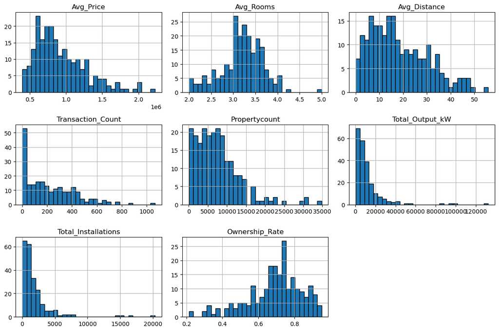

```python
# Step 2: Plot histograms to visualise distributions
import matplotlib.pyplot as plt

# Draw a histogram for every feature in X, all at once
X.hist(figsize=(12,8), bins= 30, edgecolor= 'black')

plt.tight_layout()
plt.show()
```

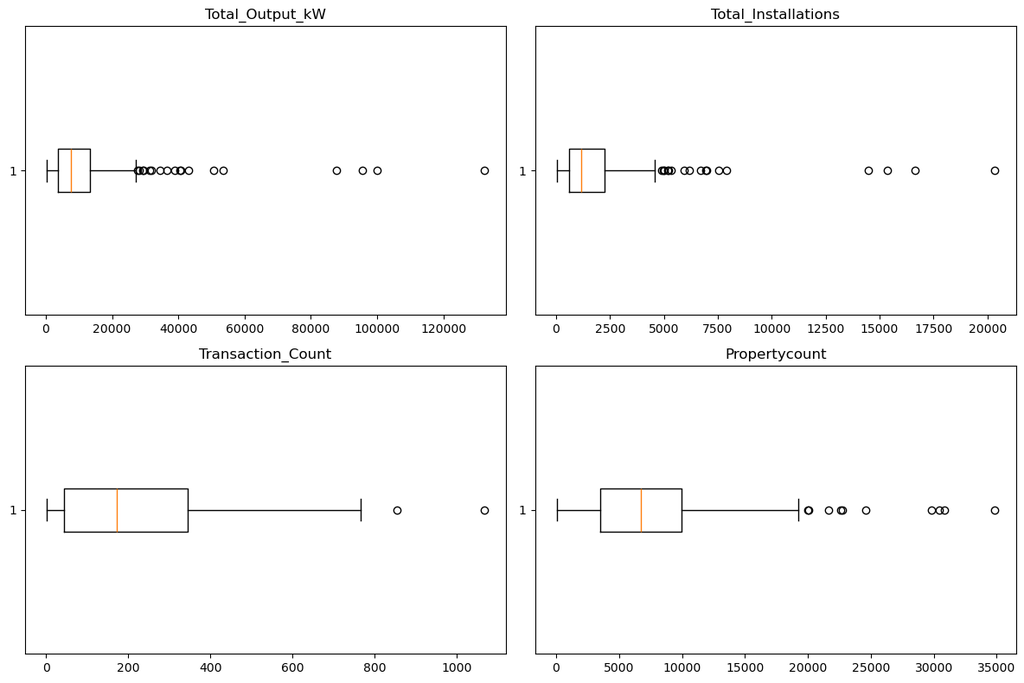

```python
# Step 3: Box plot to inspect outliers in skewed features

# The four right skewed features we want to inspect

skewed_features= [
    'Total_Output_kW',
    'Total_Installations',
    'Transaction_Count',
    'Propertycount'
]

# Create a 2x2 grid of subplots  (4 charts in one figure)
fig, axes= plt.subplots (2, 2, figsize= (12,8))

#Flatten the 2x2 grib into a simple list so we can loop through it
axes= axes.flatten()

# Loop through each feature and draw its box plot
for i, col in enumerate(skewed_features):
    axes[i].boxplot(X[col], vert=False)
    axes[i].set_title(col)

plt.tight_layout()
plt.show()
```

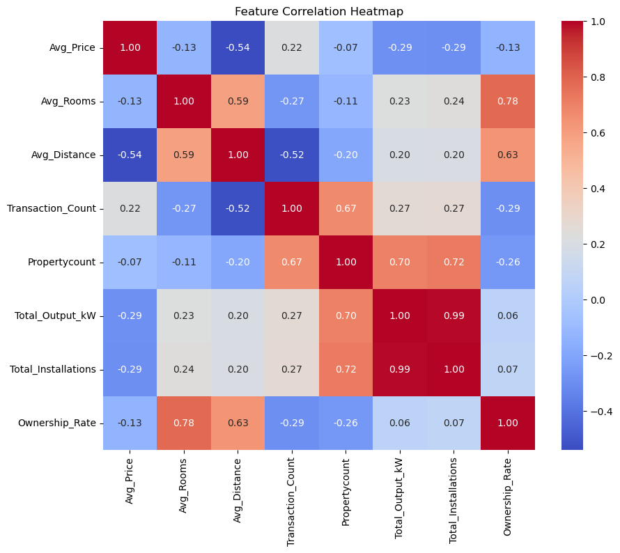

```python
# Step 4: Correlation Heatmap

import seaborn as sns

#Calculate correlation between every pair of features

corr= X.corr()

# Draw the heatmap
plt.figure(figsize=(10,8))
sns.heatmap(corr, annot=True, cmap= 'coolwarm', fmt= '.2f')
plt.title('Feature Correlation Heatmap')
plt.show()
```

**Correlation Findings**  
*The correlation matrix below is computed on the full initial feature set (before feature selection), covering all pairs with |r| ≥ 0.50.*

| Feature Pair | Correlation | Interpretation |
| --- | --- | --- |
| Total_Output_kW ↔ Total_Installations | 0.99 | Almost identical information; Total_Installations is removed to avoid redundancy |
| Ownership_Rate ↔ Avg_Rooms | 0.78 | Postcodes with higher ownership rates tend to have larger dwellings — owner-occupied areas are more likely to contain separate houses (reasonable) |
| Propertycount ↔ Total_Installations | 0.72 | Areas with more dwellings tend to have more installations (reasonable) |
| Propertycount ↔ Total_Output_kW | 0.70 | Same pattern as above (reasonable) |
| Transaction_Count ↔ Propertycount | 0.67 | Areas with more dwellings tend to have more sales (reasonable) |
| Ownership_Rate ↔ Avg_Distance | 0.63 | Postcodes further from the CBD tend to have higher ownership rates — outer suburbs have more owner-occupied separate houses (reasonable) |
| Avg_Rooms ↔ Avg_Distance | 0.59 | Dwellings further from the CBD tend to have more rooms (reasonable) |
| Avg_Price ↔ Avg_Distance | -0.54 | Prices decrease with distance from the CBD (reasonable negative relationship) |
| Avg_Distance ↔ Transaction_Count | -0.52 | Areas further from the CBD tend to have fewer property transactions (reasonable) |

**Action:**

- **Total_Output_kW & Total_Installations (r = 0.99)** is treated as redundant, so Total_Installations is removed.
- **Ownership_Rate & Avg_Rooms (r = 0.78)** is moderate-to-high; both are retained because Ownership_Rate is essential for testing Hypothesis 3, and Avg_Rooms independently represents dwelling size for Hypothesis 2. Their correlation is expected — owner-occupied postcodes tend to contain larger separate houses.

**Decision: Keep `Total_Output_kW` Drop `Total_Installations`**

> Total_Output_kW and Total_Installations are almost perfectly correlated (r = 0.99), indicating they carry nearly identical information. As the dataset covers Melbourne residential areas, solar installations are assumed to be of similar scale and specification across postcodes, which explains this near-perfect correlation. Total_Output_kW is retained because it more directly reflects solar generation capacity, aligning with ARENA's energy-focused objectives. Total_Installations is removed to avoid redundancy in the clustering features.

```python
# Update feature list--remove the redundant feature

# Total_Installations is removed because it is almost perfectly correlated with Total_Output_kW(r= 0.99)
clustering_features = [
    'Avg_Price',
    'Avg_Rooms',
    'Avg_Distance',
    'Transaction_Count',
    'Propertycount',
    'Total_Output_kW',
    'Ownership_Rate'
]

# Rebuild the feature matrix with the 6 selected features
X= df_final[clustering_features].copy()

print(f'Features matrix shape: {X.shape}')
X.head()
```

```
Features matrix shape: (221, 7)
```

|  | Avg_Price | Avg_Rooms | Avg_Distance | Transaction_Count | Propertycount | Total_Output_kW | Ownership_Rate |
| --- | --- | --- | --- | --- | --- | --- | --- |
| 0 | 7.731029e+05 | 1.995169 | 0.0 | 207 | 17496 | 2579.156 | 0.214253 |
| 1 | 1.409505e+06 | 2.078431 | 1.3 | 51 | 3040 | 760.585 | 0.447830 |
| 2 | 1.041723e+06 | 2.476923 | 3.1 | 65 | 2230 | 1829.530 | 0.323903 |
| 3 | 6.520588e+05 | 2.035294 | 0.7 | 85 | 8400 | 1321.755 | 0.303188 |
| 4 | 6.954444e+05 | 2.111111 | 1.4 | 9 | 4707 | 1792.925 | 0.303581 |

### **3-3 Feature Scaling**

K-Means measures similarity using distance, so features with large numeric range (such as Avg_Price) would otherwise dominate those with small ranges (Such as Avg_Rooms). StandardScaler is applied to bring all features onto a comparable scale.

```python
from sklearn.preprocessing import StandardScaler

# Create a scaler object
scaler= StandardScaler()

# Fit the scaler to X and transform it in one step
X_scaled= scaler.fit_transform(X)

# Convert the result back into a DataFrame (fit_transform returns a plain array)
X_scaled= pd.DataFrame(X_scaled, columns= X.columns, index= X.index)

print(f'Scaled feature matrix shape: {X_scaled.shape}')
X_scaled.head()

# Verify: after scaling, mean should be ~0 and std should be ~1
X_scaled.describe().round(2)
```

```
Scaled feature matrix shape: (221, 7)
```

|  | Avg_Price | Avg_Rooms | Avg_Distance | Transaction_Count | Propertycount | Total_Output_kW | Ownership_Rate |
| --- | --- | --- | --- | --- | --- | --- | --- |
| count | 221.00 | 221.00 | 221.00 | 221.00 | 221.00 | 221.00 | 221.00 |
| mean | -0.00 | 0.00 | -0.00 | 0.00 | 0.00 | 0.00 | 0.00 |
| std | 1.00 | 1.00 | 1.00 | 1.00 | 1.00 | 1.00 | 1.00 |
| min | -1.49 | -2.53 | -1.53 | -1.09 | -1.28 | -0.74 | -3.20 |
| 25% | -0.75 | -0.43 | -0.83 | -0.88 | -0.69 | -0.51 | -0.44 |
| 50% | -0.24 | 0.09 | -0.20 | -0.24 | -0.14 | -0.28 | 0.14 |
| 75% | 0.56 | 0.67 | 0.71 | 0.62 | 0.41 | 0.09 | 0.64 |
| max | 3.67 | 3.85 | 3.10 | 4.22 | 4.64 | 7.67 | 1.74 |

## **Phase 4: Clustering Analysis**

This phase applies K-Means clustering to group the 221 postcodes into distinct area types. The optimal number of clusters (k = 3) is determined using the Elbow method and Silhouette score, and each cluster is profiled and named based on its feature averages: Urban Core, Suburban High-Adoption Hub, and Outer Fringe.

### **4-1 Discussion of Clustering Techniques (KMeans vs Hierarchical)**

Clustering is an **unsupervised learning** technique, meaning it identifies natural grouping in data without any pre-existing labels. Unlike supervised learning, there is no "correct answer" to train against; instead, the algorithm groups records based on similarity. Several clustering algorithms exist, including K-Means, Hierarchical clustering, DBSCAN, and Gaussian Mixture Models,etc. This analysis focus on K-Means and Hierarchical clustering as the two main candidates, with K-Means selected for application.

**Why K-Means is selected technique?**

> - K-Means represents Partition-based Clustering, it divides data into a set number of groups by assigning each point to its nearest cluster centre.
> - K-Means is selected for application for two main reasons. First, its objective — partitioning data into a pre-defined number of groups directly matches the analytical goal of grouping postcodes into a small number of distinct area types. Second, K-Means produces clear cluster centres, allowing each group to be described by its average feature values (e.g average price, distance, and solar capacity), which support interpretation and reporting to ARENA.

**Why Hierarchical is discussed?**

> - Hierarchical represents Hierarchy-based Clustering - it merges similar points step by step into a tree, without needing the number of groups in advance.
> - Hierarchical clustering is discussed as an alternative because it does not require the number of clusters to be defined in advance, offering a useful contrast to K-Means and a way to observe nested structure in the data.
> - However, K-Means is preferred for application, as its number of clusters can be determined objectively (via the Elbow and Silhouette methods), and its cluster centres provide clearer, more directly interpretable group profiles.

**Why not DBSCAN and other methods?**

> - DBSCAN is a density-based method, designed to detect irregularly-shaped clusters and outliers rather than partition areas into distinct types.
> - Other approaches such as Gaussian Mixture Models (GMM) are probability-based and add complexity that is not justified for this dataset.
> - K-Means therefore offers the best balance of suitability, efficiency, and interpretability for this analysis.

**Comparison of Clustering Techniques**  
The following table summarizes the key differences between the tree techniques discussed above.

| Aspect | K-Means | Hierarchical | DBSCAN |
| --- | --- | --- | --- |
| Type | Partition-based | Hierarchy-based | Density-based |
| Number of clusters | Must be set in advance | Chosen by cutting the tree | Found automatically |
| Basis | Distance to cluster centres | Merging nearest groups | Density of points |
| Output | Cluster label per point | Tree (dendrogram) | Clusters + noise points |
| Suitable data size | Small to large | Small to medium | Small to medium |
| Best for | Partitioning into clear types | Viewing nested structure | Irregular shapes, outlier detection |
| Interpretability | High (cluster centres) | Medium (tree) | Medium |
| **Suitability for this dataset** | **Most suitable — clear area types, easy to interpret** | **Possible, but cluster count is less objective** | **Not suitable — built for outliers, not distinct types** |

**Conclusion**  
In practice, K-Means is widely used for customer and market segmentation, Hierarchical clustering for taxonomies and nested structures, and DBSCAN for anomaly detection and spatial clustering.

### **4-2 Determine Optimal K (Elbow + Silhouette)**

K-Means requires the number of clusters (k) to be specified. The Elbow method and silhouette score are used to identify a suitable value of k.

```python
# Determining the optimal number of clusters
from sklearn.cluster import KMeans
from sklearn.metrics import silhouette_score

# Try k from 2 to 10
k_range= range(2,11)

#Empty lists to store the scores for each k
inertia_list= []
silhouette_list= []

# Loop through each k, run K-Means, and record the two scores
for k in k_range:
    kmeans= KMeans(n_clusters= k, random_state= 42, n_init= 10)
    labels= kmeans.fit_predict(X_scaled)

    inertia_list.append(kmeans.inertia_)
    silhouette_list.append(silhouette_score(X_scaled,labels))

print('Done ─ scores collected for k= 2 to 10')
```

```
Done ─ scores collected for k= 2 to 10
```

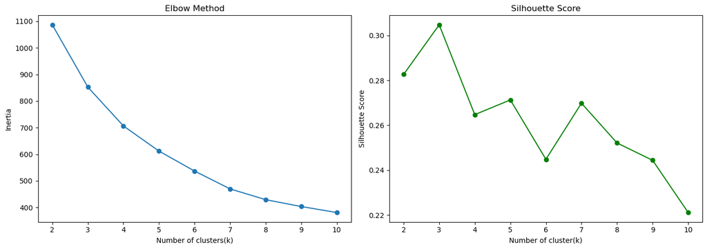

```python
# Plot Elbow and Silhouette to find the best k

fig, axes= plt.subplots(1,2, figsize=(14,5))

# Left chart: Elbow Method(inertia)
axes[0].plot(k_range, inertia_list, marker='o')
axes[0].set_title('Elbow Method')
axes[0].set_xlabel('Number of clusters(k)')
axes[0].set_ylabel('Inertia')

# Right chart: Silhouette score
axes[1].plot(k_range, silhouette_list, marker='o', color='green')
axes[1].set_title('Silhouette Score')
axes[1].set_xlabel('Number of cluster(k)')
axes[1].set_ylabel('Silhouette Score')

plt.tight_layout()
plt.show()
```

```python
# print exact Silhouette scores for transparency
for k, s in zip(k_range, silhouette_list):
    print(f'k={k} Silhouette Score= {s:4f}')
```

```
k=2 Silhouette Score= 0.282638
k=3 Silhouette Score= 0.304732
k=4 Silhouette Score= 0.264720
k=5 Silhouette Score= 0.271278
k=6 Silhouette Score= 0.244825
k=7 Silhouette Score= 0.269817
k=8 Silhouette Score= 0.252102
k=9 Silhouette Score= 0.244388
k=10 Silhouette Score= 0.221124
```

**Optimal Cluster Number Findings**

- Two methods were used to determine the optimal number of clusters: the Elbow method and the Silhouette score.
- The Elbow plot showed a gradual bend around k = 3 to 4, but the transition wasn't sharply defined.
- The Silhouette score peaked clearly at k = 3 (≈ 0.31), confirming the best-defined cluster separation at this value.
- Combining both methods, k = 3 was selected as the optimal number of clusters. This value also aligns with practical interpretability, allowing postcodes to be categorised into distinct area types for reporting to ARENA.

### **4-3 Apply KMeans**

K-Means is applied using the chosen k, assigning each postcode to a cluster.

```python
# Apply K-Means with the chosen k=3
kmeans_final= KMeans(n_clusters=3, random_state= 42, n_init= 10)
cluster_labels= kmeans_final.fit_predict(X_scaled)
# print(cluster_labels)
# Attach the cluster labels back to the main dataframe
df_final['Cluster']= cluster_labels

# Check how many postcodes fall into each cluster
print(df_final['Cluster'].value_counts())

df_final.head()
```

```
Cluster
1    104
0     98
2     19
Name: count, dtype: int64
```

[output not shown]

**Applying K-Means Findings**

- K-Means was applied with k = 3, assigning each of the 221 postcodes to one of three clusters.
- The clusters vary in size: Cluster 1 (104 postcodes) and Cluster 0 (98 postcodes) are the two main groups, while Cluster 2 is notably smaller (19 postcodes).
- Importantly, no cluster is near-empty, suggesting the smaller Cluster 2 still represents a genuine group rather than noise — likely a distinct set of postcodes with atypical characteristics.

### **4-4 Cluster Interpretation**

Each cluster is characterised by its feature averages to interpret what type of area it represents.

**Step 1: Cluster Feature Averages**  
To understand what each cluster represents, the mean value of every feature is calculated per cluster. This produces a profile table- each row is a cluster, each column is a feature, and the values show the average characteristics of postcodes in that group.

```python
# Step 1: Calculate cluster feature averages

# Group all 221 postcodes by their Cluster label(0,1,2), then calculate the mean of each feature within each group.
cluster_profile= df_final.groupby('Cluster')[clustering_features].mean()

# Round all values to 2 decimal places for readability
cluster_profile= cluster_profile.round(2)

# Display the profile table
cluster_profile
```

| Cluster | Avg_Price | Avg_Rooms | Avg_Distance | Transaction_Count | Propertycount | Total_Output_kW | Ownership_Rate |
| --- | --- | --- | --- | --- | --- | --- | --- |
| 0 | 762478.58 | 3.47 | 27.46 | 72.16 | 4248.71 | 9842.56 | 0.80 |
| 1 | 1125150.62 | 2.88 | 9.10 | 317.74 | 8230.90 | 7392.22 | 0.59 |
| 2 | 679151.98 | 3.39 | 23.23 | 437.63 | 20906.11 | 46591.90 | 0.69 |

**Cluster Profile Summary**

| Cluster | Size | Label | Key Characteristics |
| --- | --- | --- | --- |
| 0 | 98 | Outer Fringe | Furthest from CBD (27.46 km), largest dwellings (3.47 rooms), highest ownership rate (0.80), but smallest communities (4,249 properties) and fewest transactions (72) — outer or semi-rural postcodes wi… |
| 1 | 104 | Urban Core | Closest to CBD (9.10 km), highest property prices ($1.13M), smallest dwellings (2.88 rooms), lowest ownership rate (0.59), lowest solar output (7,392 kW) — inner-city postcodes dominated by apartments… |
| 2 | 19 | Suburban High-Adoption Hub | Largest residential areas (20,906 properties), highest solar output (46,592 kW), most transactions (438), moderate ownership rate (0.69). Despite being only 19 postcodes, this cluster leads in solar a… |

**Step 2: Cluster profile visualisation(Scaled Values)**  
A grouped bar chart is used to compare the three clusters across all features simultaneously. Standardised (Z-score) values are used instead of raw values, because the original features have very different scales ─property price are in millions while room counts are around 3. Plotting them together on the same axis in raw form would make smaller-scale features invisible.

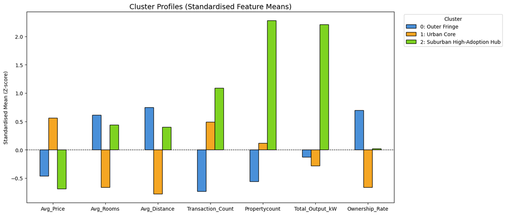

```python
# Step 2: Visualise cluster profile using scaled values

# Calculate the mean of each feature per cluster, using the SCALED data.
cluster_profile_scaled= X_scaled.groupby(df_final['Cluster']).mean()

# Round to decimal places for clearner axis labels
cluster_profile_scaled= cluster_profile_scaled.round(2)

# Create the grouped bar chart
# figsize= (14,6)
ax= cluster_profile_scaled.T.plot(kind= 'bar', figsize=(14,6), edgecolor='black',
                                  color=['#4A90D9', '#F5A623', '#7ED321'])

# Add chart title
ax.set_title('Cluster Profiles (Standardised Feature Means)', fontsize=14)

# Label the y-axis to indicate values are in standard deviations from the mean.
ax.set_ylabel('Standardised Mean (Z-score)')

# Add a horizontal line at y=0 to show the overall average baseline
ax.axhline(y= 0, color= 'black', linewidth= 0.8, linestyle= '--')

# Rotate x-axis labels so feature names are horizontal and easier to read.
ax.set_xticklabels(ax.get_xticklabels(), rotation= 0)

# placce the legend outside the chart area to avoid blocking the bars.
legend_elements = [
    Patch(facecolor='#4A90D9', edgecolor='black', label='0: Outer Fringe'),
    Patch(facecolor='#F5A623', edgecolor='black', label='1: Urban Core'),
    Patch(facecolor='#7ED321', edgecolor='black', label='2: Suburban High-Adoption Hub')
]
ax.legend(handles=legend_elements, title='Cluster', bbox_to_anchor=(1.02, 1))

plt.tight_layout()
plt.show()
```

**Step 3: Cluster Naming and Interpretation**

Based on the feature averages and the standardised profile chart above, each cluster is assigned a descriptive label that reflects its dominant characteristics.

| Cluster | Size | Label | Profile Summary |
| --- | --- | --- | --- |
| 0 | 98 | Outer Fringe | Furthest from CBD (27.46 km), largest dwellings (3.47 rooms), highest ownership rate (0.80), but smallest communities (4,249 properties) and fewest transactions (72). These outer and semi-rural postco… |
| 1 | 104 | Urban Core | Closest to CBD (9.10 km), highest property prices ($1.13M), smallest dwellings (2.88 rooms), lowest ownership rate (0.59), lowest solar output (7,392 kW). These are inner-city postcodes dominated by a… |
| 2 | 19 | Suburban High-Adoption Hub | Largest residential areas (20,906 properties), highest solar output (46,592 kW), most transactions (438), moderate ownership rate (0.69). Despite being only 19 postcodes, this cluster leads in solar a… |

**Key Observations:**

- Cluster 2 (Suburban High-Adoption Hub) demonstrates the strongest solar adoption despite containing only 19 postcodes. The combination of large community scale, high transaction volume, and moderate distance from the CBD creates ideal conditions for residential solar uptake. Notably, this cluster does not have the highest ownership rate — suggesting that community scale is a stronger driver of total solar output than ownership proportion alone.
- Cluster 0 (Outer Fringe) has the highest ownership rate (0.80) and largest dwellings, yet its total solar output is only moderate. This suggests that while ownership and housing conditions are favourable, small population size limits total adoption — representing an opportunity for ARENA to promote solar in communities with untapped potential.
- Cluster 1 (Urban Core) faces structural barriers to solar adoption, as high-density dwellings and the lowest ownership rate (0.59) make rooftop solar less feasible in these areas.

These cluster profiles provide an initial view of solar adoption patterns. Phase 5 applies regression and residual analysis to identify specific priority postcodes within each cluster, which may reveal opportunities beyond what cluster-level averages suggest.

**Phase 4 Summary**

Phase 4 applied K-Means clustering to group 221 Melbourne postcodes into three distinct area types based on *seven features*:  
Avg_Price, Avg_Rooms, Avg_Distance, Transaction_Count, Propertycount, Total_Output_kW, and Ownership_Rate.

**Method:**

- K-Means was selected over Hierarchical clustering for its clear cluster centres and suitability for partitioning postcodes into interpretable groups.
- The optimal number of clusters (k = 3) was determined using the Elbow method and Silhouette score, with k = 3 achieving the highest Silhouette score (≈ 0.31).

**Results:**

| Cluster | Label | Size | Solar Output | Distance | Key Trait |
| --- | --- | --- | --- | --- | --- |
| 0 | Outer Fringe | 98 | Moderate (9,843 kW) | Furthest (27.46 km) | Large dwellings, highest ownership rate, small populations |
| 1 | Urban Core | 104 | Lowest (7,392 kW) | Nearest (9.10 km) | High-density, high-price, lowest ownership rate |
| 2 | Suburban High-Adoption Hub | 19 | Highest (46,592 kW) | Moderate (23.23 km) | Largest communities, strongest adoption |

**Implications for Phase 5:**

- Cluster 2 demonstrates that community scale — not ownership rate — is the primary driver of total solar output, as it leads in adoption despite having only a moderate ownership rate (0.69).
- Cluster 0 identifies postcodes where ownership rate and housing conditions are most favourable for solar, but small population size limits total adoption — these are candidates for ARENA's priority list (Business Question 2).
- Cluster 1 highlights structural barriers in inner-city areas that limit rooftop solar feasibility.

## **Phase 5: Interpretation & Presentation**

Phase 4 grouped 221 Melbourne postcodes into three clusters based on shared characteristics. Phase 5 now interprets these results by testing the three business hypotheses, answering the two business questions, and producing actionable recommendations for ARENA.

### **5-1 Regression Analysis**

Build a statistical model to quantity how distance(H1), dwelling size (H2), and ownership rate (H3) each relate to solar adoption.

A multiple linear regression (Ordinary Least Squares, OLS) is used to quantify how each hypothesised factor relates to solar adoption. The dependent variable is Total_Output_kW, and the independent variables are Avg_Distance (H1), Avg_Rooms (H2), and Ownership_Rate (H3). The regression output provides coefficients, p-values, and R-squared to support hypothesis testing in Section 5-2.

```python
import statsmodels.api as sm

# Define the dependent variable(Y): the thing we want to explain
Y= df_final['Total_Output_kW']
# Define the independent variables (X): the three hypothesised factors
# Avg_Distance(H1), Avg_Rooms(H2), Ownership_Rate(H3)
X_reg= df_final[['Avg_Distance', 'Avg_Rooms', 'Ownership_Rate']]

# Add a constant(intercept) to the model
X_reg= sm.add_constant(X_reg)

#Fit the OLS regression model
model= sm.OLS(Y, X_reg).fit()

#Display the full regression summary
print(model.summary())
```

```
                            OLS Regression Results
==============================================================================
Dep. Variable:        Total_Output_kW   R-squared:                       0.112
Model:                            OLS   Adj. R-squared:                  0.100
Method:                 Least Squares   F-statistic:                     9.131
Date:                Thu, 11 Jun 2026   Prob (F-statistic):           1.02e-05
Time:                        10:02:33   Log-Likelihood:                -2435.7
No. Observations:                 221   AIC:                             4879.
Df Residuals:                     217   BIC:                             4893.
Df Model:                           3
Covariance Type:            nonrobust
==================================================================================
                     coef    std err          t      P>|t|      [0.025      0.975]
----------------------------------------------------------------------------------
const          -8894.8769   7527.441     -1.182      0.239   -2.37e+04    5941.381
Avg_Distance     260.3443    110.046      2.366      0.019      43.448     477.241
Avg_Rooms       1.403e+04   3482.306      4.029      0.000    7165.230    2.09e+04
Ownership_Rate -4.159e+04   1.15e+04     -3.622      0.000   -6.42e+04    -1.9e+04
==============================================================================
Omnibus:                      230.913   Durbin-Watson:                   1.602
Prob(Omnibus):                  0.000   Jarque-Bera (JB):             6624.531
Skew:                           4.215   Prob(JB):                         0.00
Kurtosis:                      28.463   Cond. No.                         260.
==============================================================================

Notes:
[1] Standard Errors assume that the covariance matrix of the errors is correctly specified.
```

**Scatter Plot with regression line**  
To visually assess the relationship between each hypothesised factor and solar output, scatter plots are drawn with a fitted regression line. Each dot represents one postcode.

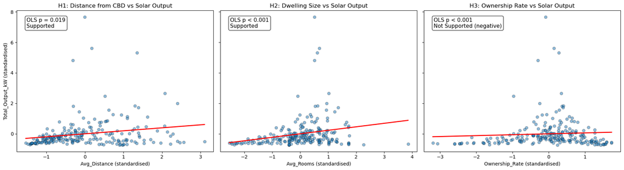

```python
#Scatter plots with regression lines (Standardised, OLS p-values)

import matplotlib.pyplot as plt
import numpy as np
from scipy import stats

# Define hypothesis variables, titles, and the p-values FROM the OLS model.
hypothesis_info = [
    ('Avg_Distance', 'H1: Distance from CBD vs Solar Output', 0.019, 'Supported'),
    ('Avg_Rooms', 'H2: Dwelling Size vs Solar Output', 0.000, 'Supported'),
    ('Ownership_Rate', 'H3: Ownership Rate vs Solar Output', 0.000, 'Not Supported (negative)')
]

# Create a row of 3 subplots with shared y-axis.
fig, axes = plt.subplots(1, 3, figsize=(18, 5), sharey=True)

for i, (var, title, ols_p, verdict) in enumerate(hypothesis_info):

    # Get standardised values.
    x_vals = X_scaled[var]
    y_vals = X_scaled['Total_Output_kW']

    # Draw scatter plot.
    axes[i].scatter(x_vals, y_vals, alpha=0.5, edgecolors='black', linewidth=0.5)

    # Fit and draw the regression line.
    slope, intercept, r_value, _, _ = stats.linregress(x_vals, y_vals)
    x_sorted = np.sort(x_vals)
    axes[i].plot(x_sorted, slope * x_sorted + intercept, color='red', linewidth=2)

    # Display OLS p-value and verdict on chart.
    p_text = 'p < 0.001' if ols_p < 0.001 else f'p = {ols_p:.3f}'
    axes[i].text(0.05, 0.95, f'OLS {p_text}\n{verdict}',
                 transform=axes[i].transAxes, fontsize=11,
                 verticalalignment='top',
                 bbox=dict(boxstyle='round', facecolor='white', alpha=0.8))

    # Set title and labels.
    axes[i].set_title(title, fontsize=12)
    axes[i].set_xlabel(f'{var} (standardised)')
    if i == 0:
        axes[i].set_ylabel('Total_Output_kW (standardised)')

plt.tight_layout()
plt.show()
```

**Regression Findings**

| Variable | Coefficient | p-value | Significant (p < 0.05)? |
| --- | --- | --- | --- |
| Avg_Distance (H1) | +260.34 | 0.019 | Yes |
| Avg_Rooms (H2) | +14,030 | < 0.001 | Yes |
| Ownership_Rate (H3) | -41,590 | < 0.001 | Yes — but negative direction |

- **R² = 0.112:** The three factors together explain 11.2% of the variation in solar output across postcodes. The relatively low R² indicates that other unmeasured factors (such as community scale, government subsidies, or installer access) play a larger role.
- **Strongest predictor:** Avg_Rooms (t = 4.03), followed by Ownership_Rate (t = -3.62) and Avg_Distance (t = 2.37).
- **Unexpected finding:** Ownership_Rate has a significant but negative coefficient, meaning postcodes with higher ownership rates tend to have lower total solar output — contrary to H3's prediction. This is likely because high-ownership postcodes tend to be smaller communities (Cluster 0, Outer Fringe) with less total capacity, while the largest solar output comes from large-scale suburban areas (Cluster 2) with moderate ownership rates.

These results are interpreted in Section 5-2 for formal hypothesis testing.

### **5-2 Hypothesis Testing**

Use the regression results to formally assess whether each hypothesis is supported or not supported.

The OLS regression results from Section 5-1 are used to formally assess each hypothesis. A hypothesis is considered **Supported** when the coefficient sign matches the predicted direction **and** the p-value is below 0.05 (statistically significant). Otherwise, it is **Not Supported**.

**H1: Postcodes further from the CBD have higher solar adoption.**

- Predicted direction: Positive (further → higher)
- Coefficient: +260.34 (positive — matches prediction)
- p-value: 0.019 (statistically significant)
- **Result: Supported.**

> Each additional kilometre from the CBD is associated with an average increase of 260 kW in solar output, holding other factors constant. Outer suburbs typically contain more separate houses with suitable roof space, which explains the higher adoption.

**H2: Postcodes with larger dwellings (more rooms) have higher solar adoption.**

- Predicted direction: Positive (more rooms → higher)
- Coefficient: +14,030 (positive — matches prediction)
- p-value: < 0.001 (statistically significant)
- **Result: Supported.**

> Each additional average room per postcode is associated with an increase of approximately 14,030 kW in solar output. Larger dwellings typically indicate separate houses with greater roof area suitable for solar panel installation, as opposed to apartments or townhouses with limited or shared roof space.

**H3: Postcodes with higher home-ownership rates have higher solar adoption.**

- Predicted direction: Positive (higher ownership → higher)
- Coefficient: -41,590 (negative — opposite to prediction)
- p-value: < 0.001 (statistically significant, but wrong direction)
- **Result: Not Supported.**

> Although the relationship is statistically significant, the coefficient is negative — meaning postcodes with higher ownership rates actually tend to have lower total solar output. This counterintuitive finding is explained by the cluster profiles: the highest-ownership postcodes (Cluster 0, Outer Fringe, ownership rate = 0.80) are small communities with limited total capacity, while the highest solar output comes from Cluster 2 (Suburban High-Adoption Hub, ownership rate = 0.69), where large community scale drives total adoption regardless of ownership proportion. This suggests that at the postcode level, total solar output is driven more by community scale and dwelling type than by ownership rate alone.

**Summary:**

| Hypothesis | Variable | Direction | p-value | Result |
| --- | --- | --- | --- | --- |
| H1 | Avg_Distance | + (as predicted) | 0.019 | Supported |
| H2 | Avg_Rooms | + (as predicted) | < 0.001 | Supported |
| H3 | Ownership_Rate | − (opposite to predicted) | < 0.001 | Not Supported |

### **5-3 Findings for Business Question 1**

Summarise which area characteristics are associated with solar adoption.

**BQ1: Which area characteristics are associated with residential solar adoption across Melbourne postcodes?**

The regression analysis (Section 5-1) and cluster profiles (Section 4-4) together identify two key area characteristics associated with solar adoption:

**1. Dwelling size (strongest factor)** Avg_Rooms is the strongest predictor of solar output (coefficient = +14,030, p < 0.001, t = 4.03). Larger dwellings indicate separate houses with greater roof area suitable for solar installation. This is consistent with the cluster profiles: Cluster 2 (Suburban High-Adoption Hub) has the highest solar output and consists of areas with predominantly separate houses.

**2. Distance from the CBD (secondary factor)** Avg_Distance is positively associated with solar output (coefficient = +260.34, p = 0.019). Outer suburbs contain more separate houses with suitable roof space. The cluster map below shows that high-adoption postcodes (Cluster 2, green) are located in the middle-ring suburbs, while the lowest-output postcodes (Cluster 1, orange) cluster around the CBD.

**3. Home ownership rate (significant but negative — not associated as predicted)** Ownership_Rate has a significant but negative relationship with solar output (coefficient = -41,590, p < 0.001). Postcodes with the highest ownership rates (Cluster 0, Outer Fringe, 0.80) are small communities with limited total solar capacity, while the highest solar output comes from large-scale suburban areas (Cluster 2) with moderate ownership rates (0.69). This suggests that at the postcode level, community scale matters more than ownership proportion for total solar output.

**Cluster Distribution Map** The map below visualises the geographic distribution of the three clusters across Melbourne, showing how solar adoption patterns align with location.

```python
# Add Latitude and Longitude to df_final

# From the original housing data, calculate the average Latitude and Longitude per postcode.
postcode_coords = df_house.groupby('Postcode')[['Latitude', 'Longitude']].mean()

# Check how many postcodes have valid coordinates (not NaN).
print(f"Postcodes with valid coordinates: {postcode_coords.dropna().shape[0]}")
print(f"Postcodes with missing coordinates: {postcode_coords.isna().any(axis=1).sum()}")

# Merge the coordinates into df_final.
df_final = df_final.merge(postcode_coords, on='Postcode', how='left')

# Check the result.
print(f"\ndf_final shape: {df_final.shape}")
print(f"Rows with missing Latitude: {df_final['Latitude'].isna().sum()}")
df_final[['Postcode', 'Latitude', 'Longitude']].head()
```

```
Postcodes with valid coordinates: 208
Postcodes with missing coordinates: 13

df_final shape: (221, 13)
Rows with missing Latitude: 13
```

|  | Postcode | Latitude | Longitude |
| --- | --- | --- | --- |
| 0 | 3000 | -37.812860 | 144.963389 |
| 1 | 3002 | -37.814904 | 144.985244 |
| 2 | 3003 | -37.808305 | 144.947588 |
| 3 | 3006 | -37.826390 | 144.964872 |
| 4 | 3008 | -37.817433 | 144.943200 |

```python
# Cluster Distribution Map (Folium)

import folium

# Melbourne CBD coordinates as the map centre.
melb_coords = [-37.8136, 144.9631]

# Create a base map centred on Melbourne, zoom level 10 shows the greater metro area.
m = folium.Map(location=melb_coords, zoom_start=10, tiles='CartoDB Positron')

# Define a colour for each cluster.
cluster_colors = {0: 'blue', 1: 'orange', 2: 'green'}

# Define the cluster labels for popup text.
cluster_labels = {
    0: 'Outer Fringe',
    1: 'Urban Core',
    2: 'Suburban High-Adoption Hub'
    }

# Filter out postcodes with missing coordinates (13 postcodes have no lat/lng).
df_map = df_final.dropna(subset=['Latitude', 'Longitude'])

# Loop through each postcode and add a circle marker to the map.
for _, row in df_map.iterrows():

    folium.CircleMarker(
        # Place the marker at the postcode's average lat/lng.
        location=[row['Latitude'], row['Longitude']],

        # Circle size = 6 pixels.
        radius=6,

        # Fill colour based on cluster.
        color=cluster_colors[row['Cluster']],
        fill=True,
        fill_color=cluster_colors[row['Cluster']],
        fill_opacity=0.7,

        # Popup shows postcode, cluster name, and solar output when clicked.
        popup=f"Postcode: {int(row['Postcode'])}<br>"
              f"Cluster: {cluster_labels[row['Cluster']]}<br>"
              f"Solar Output: {row['Total_Output_kW']:.0f} kW"
    ).add_to(m)

# Display the map.
m
```

Make this Notebook Trusted to load map: File -> Trust Notebook

[interactive chart not shown]

```python
m.save('cluster_map.html')
print('Map saved as cluster_map.html')
```

```
Map saved as cluster_map.html
```

**Map Interpretation**

The cluster map confirms a clear geographic pattern across Melbourne:

- **Orange (Cluster 1 — Urban Core):**

Concentrated around the CBD and inner suburbs, where high-density housing and the lowest ownership rate (0.59) limit rooftop solar feasibility.

- **Green (Cluster 2 — Suburban High-Adoption Hub):**

A small number of postcodes (19) scattered across the middle-ring suburbs. Despite their small count, these large-scale communities produce the highest total solar output, driven by high property counts and active housing markets.

- **Blue (Cluster 0 — Outer Fringe):**

Distributed across the outer metropolitan boundary and semi-rural areas. These postcodes have the highest ownership rate (0.80) and largest dwellings, but small population sizes limit their total solar output.

This geographic distribution supports the regression findings: solar adoption increases with distance from the CBD (H1 — Supported) and with dwelling size (H2 — Supported), while ownership rate alone does not drive total adoption at the postcode level (H3 — Not Supported).

*Note: 13 of 221 postcodes are excluded from the map due to missing coordinate data in the original dataset.*

### **5-4 Findings for Business Question 2**

Identify postcodes with suitable conditions but low adoption.

**BQ2: Which postcodes show suitable conditions for solar but currently have low adoption?**

To identify priority postcodes for ARENA, a "solar gap" approach is used. Postcodes are considered high-potential if they have favourable physical conditions for solar (large dwellings, moderate-to-far distance from CBD) but their actual solar output falls below expectations. Specifically, the residuals from the regression model in Section 5-1 are used: a large negative residual means a postcode is producing significantly less solar output than the model predicts based on its characteristics — indicating untapped potential.

```python
# 5-4 Identify high-potential low-adoption postcodes ----------

# Step 1: Get the predicted solar output from the regression model.
df_final['Predicted_kW'] = model.predict(X_reg)

# Step 2: Calculate the residual (actual minus predicted).
df_final['Residual'] = df_final['Total_Output_kW'] - df_final['Predicted_kW']

# Step 3: Sort by residual (ascending) to find the biggest underperformers.
gap_postcodes = df_final.sort_values('Residual').head(20)

# Step 4: Display the top 20 underperforming postcodes.
print("Top 20 postcodes with the largest solar gap (actual << predicted):\n")
gap_postcodes[['Postcode', 'Cluster', 'Avg_Distance', 'Avg_Rooms',
               'Ownership_Rate', 'Total_Output_kW', 'Predicted_kW', 'Residual']].round(0)
```

```
Top 20 postcodes with the largest solar gap (actual << predicted):
```

|  | Postcode | Cluster | Avg_Distance | Avg_Rooms | Ownership_Rate | Total_Output_kW | Predicted_kW | Residual |
| --- | --- | --- | --- | --- | --- | --- | --- | --- |
| 191 | 3759 | 0 | 28.0 | 5.0 | 1.0 | 1363.0 | 30134.0 | -28772.0 |
| 167 | 3200 | 0 | 37.0 | 3.0 | 1.0 | 1949.0 | 23048.0 | -21099.0 |
| 50 | 3063 | 0 | 24.0 | 4.0 | 1.0 | 658.0 | 20387.0 | -19728.0 |
| 178 | 3341 | 0 | 45.0 | 4.0 | 1.0 | 1540.0 | 20557.0 | -19018.0 |
| 198 | 3781 | 0 | 42.0 | 4.0 | 1.0 | 2304.0 | 20859.0 | -18554.0 |
| 136 | 3168 | 1 | 17.0 | 3.0 | 0.0 | 8089.0 | 25800.0 | -17711.0 |
| 18 | 3027 | 0 | 18.0 | 4.0 | 1.0 | 6292.0 | 23700.0 | -17408.0 |
| 202 | 3791 | 0 | 32.0 | 4.0 | 1.0 | 902.0 | 18212.0 | -17310.0 |
| 40 | 3052 | 1 | 2.0 | 3.0 | 0.0 | 1714.0 | 18122.0 | -16408.0 |
| 182 | 3431 | 0 | 47.0 | 4.0 | 1.0 | 4286.0 | 20485.0 | -16199.0 |
| 41 | 3053 | 1 | 2.0 | 3.0 | 0.0 | 1580.0 | 16979.0 | -15399.0 |
| 204 | 3795 | 0 | 35.0 | 4.0 | 1.0 | 2161.0 | 17161.0 | -14999.0 |
| 184 | 3438 | 0 | 48.0 | 4.0 | 1.0 | 2623.0 | 17221.0 | -14597.0 |
| 144 | 3177 | 0 | 29.0 | 3.0 | 1.0 | 5182.0 | 19193.0 | -14012.0 |
| 97 | 3125 | 1 | 10.0 | 3.0 | 1.0 | 5800.0 | 18839.0 | -13039.0 |
| 77 | 3096 | 0 | 24.0 | 4.0 | 1.0 | 1213.0 | 13368.0 | -12155.0 |
| 203 | 3793 | 0 | 34.0 | 4.0 | 1.0 | 3388.0 | 14879.0 | -11491.0 |
| 2 | 3003 | 1 | 3.0 | 2.0 | 0.0 | 1830.0 | 13189.0 | -11360.0 |
| 147 | 3180 | 0 | 23.0 | 4.0 | 1.0 | 6669.0 | 17794.0 | -11126.0 |
| 212 | 3808 | 0 | 40.0 | 4.0 | 1.0 | 3222.0 | 14194.0 | -10972.0 |

**Solar Gap Findings**

These postcodes are carried forward to Section 5-5 as ARENA's priority targets.

```python
# Priority Postcodes Map
import folium

melb_coords = [-37.8136, 144.9631]

# Use CartoDB Positron tile for a cleaner, lighter background.
m2 = folium.Map(location=melb_coords, zoom_start=10, tiles='CartoDB Positron')

# Prepare data.

priority = df_final.sort_values('Residual').head(20)
df_map_all = df_final.dropna(subset=['Latitude', 'Longitude'])
priority_map = priority.dropna(subset=['Latitude', 'Longitude'])

# Cluster colours for background layer.
cluster_colors = {0: '#4A90D9', 1: '#F5A623', 2: '#7ED321'}
cluster_labels = {0: 'Outer Fringe', 1: 'Urban Core', 2: 'Suburban High-Adoption Hub'}

# Background layer: all postcodes coloured by cluster.
for _, row in df_map_all.iterrows():
    folium.CircleMarker(
        location=[row['Latitude'], row['Longitude']],
        radius=5,
        color=cluster_colors[row['Cluster']],
        fill=True,
        fill_color=cluster_colors[row['Cluster']],
        fill_opacity=0.4,
        popup=f"<b>PRIORITY</b><br>"
            f"Postcode: {int(row['Postcode'])}<br>"
            f"Council: {row['CouncilArea']}<br>"
            f"Cluster: {cluster_labels[row['Cluster']]}<br>"
            f"Actual: {row['Total_Output_kW']:.0f} kW<br>"
            f"Predicted: {row['Predicted_kW']:.0f} kW<br>"
            f"Gap: {row['Residual']:.0f} kW"
            ).add_to(m2)

# Priority layer: red circles sized by the magnitude of the gap.
max_gap = abs(priority_map['Residual'].min())
for _, row in priority_map.iterrows():
    # Scale radius between 8 and 20 based on gap size.

    scaled_radius = 8 + (abs(row['Residual']) / max_gap) * 12

    folium.CircleMarker(
        location=[row['Latitude'], row['Longitude']],
        radius=scaled_radius,
        color='red',
        fill=True,
        fill_color='red',
        fill_opacity=0.7,
        popup=f"<b>PRIORITY</b><br>"
              f"Postcode: {int(row['Postcode'])}<br>"
              f"Council: {row['CouncilArea']}<br>"
              f"Cluster: {cluster_labels[row['Cluster']]}<br>"
              f"Actual: {row['Total_Output_kW']:.0f} kW<br>"
              f"Predicted: {row['Predicted_kW']:.0f} kW<br>"
              f"Gap: {row['Residual']:.0f} kW"
    ).add_to(m2)

m2
```

Make this Notebook Trusted to load map: File -> Trust Notebook

[interactive chart not shown]

```python
# Save
m2.save('priority_postcodes_map.html')
print('Map saved as priority_postcodes_map.html')
```

```
Map saved as priority_postcodes_map.html
```

**Priority Map Interpretation**

The map highlights the 20 postcodes with the largest solar gap (red circles) against the background of all Melbourne postcodes (coloured by cluster). Larger red circles indicate a greater gap between predicted and actual solar output.

Key patterns:

These 20 postcodes are formalised as ARENA's priority list in Section 5-5.

### **5-5 Priority Postcodes for ARENA**

Present the specific postcodes ARENA should target.

Based on the solar gap analysis in Section 5-4, the following table presents the 20 postcodes recommended as priority targets for ARENA's solar promotion efforts. These postcodes were identified by their large negative regression residuals — meaning their actual solar output is significantly lower than what their area characteristics (distance, dwelling size, ownership rate) would predict.

```python
# 5-5 Priority Postcodes Table

# Get the top 20 priority postcodes sorted by residual (largest gap first).
priority = df_final.sort_values('Residual').head(20).copy()

# Add a rank column (1 = largest gap).
priority['Rank'] = range(1, len(priority) + 1)

# Add cluster labels for readability.
cluster_labels = {0: 'Outer Fringe', 1: 'Urban Core', 2: 'Suburban High-Adoption Hub'}
priority['Cluster_Label'] = priority['Cluster'].map(cluster_labels)

# Calculate the gap as a percentage of predicted output.
priority['Gap_Pct'] = ((priority['Residual'] / priority['Predicted_kW']) * 100).round(1)

# Display the final priority table.
priority[['Rank', 'Postcode', 'Cluster_Label', 'CouncilArea', 'Avg_Distance', 'Ownership_Rate',
          'Total_Output_kW', 'Predicted_kW', 'Residual', 'Gap_Pct']].rename(
    columns={
        'Cluster_Label': 'Area Type',
        'CouncilArea': 'Council',
        'Avg_Distance': 'Distance (km)',
        'Ownership_Rate': 'Ownership',
        'Total_Output_kW': 'Actual (kW)',
        'Predicted_kW': 'Predicted (kW)',
        'Residual': 'Gap (kW)',
        'Gap_Pct': 'Gap (%)'
    }
)
```

|  | Rank | Postcode | Area Type | Council | Distance (km) | Ownership | Actual (kW) | Predicted (kW) | Gap (kW) | Gap (%) |
| --- | --- | --- | --- | --- | --- | --- | --- | --- | --- | --- |
| 191 | 1 | 3759 | Outer Fringe | Nillumbik Shire Council | 28.4 | 0.925926 | 1362.653 | 30134.359656 | -28771.706656 | -95.5 |
| 167 | 2 | 3200 | Outer Fringe | Frankston City Council | 36.9 | 0.521415 | 1949.360 | 23047.945974 | -21098.585974 | -91.5 |
| 50 | 3 | 3063 | Outer Fringe | Hume City Council | 24.3 | 0.881657 | 658.105 | 20386.515816 | -19728.410816 | -96.8 |
| 178 | 4 | 3341 | Outer Fringe | Moorabool Shire Council | 45.2 | 0.924051 | 1539.860 | 20557.430733 | -19017.570733 | -92.5 |
| 198 | 5 | 3781 | Outer Fringe | Cardinia Shire Council | 42.1 | 0.897402 | 2304.247 | 20858.656734 | -18554.409734 | -89.0 |
| 136 | 6 | 3168 | Urban Core | Monash City Council | 16.7 | 0.373846 | 8089.170 | 25800.324586 | -17711.154586 | -68.6 |
| 18 | 7 | 3027 | Outer Fringe | Wyndham City Council | 17.6 | 0.582005 | 6292.168 | 23700.302920 | -17408.134920 | -73.5 |
| 202 | 8 | 3791 | Outer Fringe | Yarra Ranges Shire Council | 31.6 | 0.895307 | 902.147 | 18212.164993 | -17310.017993 | -95.0 |
| 40 | 9 | 3052 | Urban Core | Melbourne City Council | 1.8 | 0.325419 | 1714.330 | 18121.999082 | -16407.669082 | -90.5 |
| 182 | 10 | 3431 | Outer Fringe | Macedon Ranges Shire Council | 47.4 | 0.867286 | 4286.121 | 20484.804879 | -16198.683879 | -79.1 |
| 41 | 11 | 3053 | Urban Core | Melbourne City Council | 1.6 | 0.233984 | 1579.843 | 16979.243812 | -15399.400812 | -90.7 |
| 204 | 12 | 3795 | Outer Fringe | Yarra Ranges Shire Council | 34.6 | 0.826923 | 2161.461 | 17160.956091 | -14999.495091 | -87.4 |
| 184 | 13 | 3438 | Outer Fringe | Macedon Ranges Shire Council | 48.1 | 0.866750 | 2623.414 | 17220.714798 | -14597.300798 | -84.8 |
| 144 | 14 | 3177 | Outer Fringe | Casey City Council | 28.8 | 0.536712 | 5181.532 | 19193.210926 | -14011.678926 | -73.0 |
| 97 | 15 | 3125 | Urban Core | Monash City Council | 10.4 | 0.572684 | 5799.917 | 18838.573782 | -13038.656782 | -69.2 |
| 77 | 16 | 3096 | Outer Fringe | Nillumbik Shire Council | 23.6 | 0.919540 | 1212.990 | 13367.988454 | -12154.998454 | -90.9 |
| 203 | 17 | 3793 | Outer Fringe | Yarra Ranges Shire Council | 34.1 | 0.822444 | 3388.011 | 14878.934313 | -11490.923313 | -77.2 |
| 2 | 18 | 3003 | Urban Core | Melbourne City Council | 3.1 | 0.323903 | 1829.530 | 13189.485480 | -11359.955480 | -86.1 |
| 147 | 19 | 3180 | Outer Fringe | Knox City Council | 23.3 | 0.735729 | 6668.573 | 17794.193923 | -11125.620923 | -62.5 |
| 212 | 20 | 3808 | Outer Fringe | Cardinia Shire Council | 39.8 | 0.930811 | 3222.225 | 14194.190133 | -10971.965133 | -77.3 |

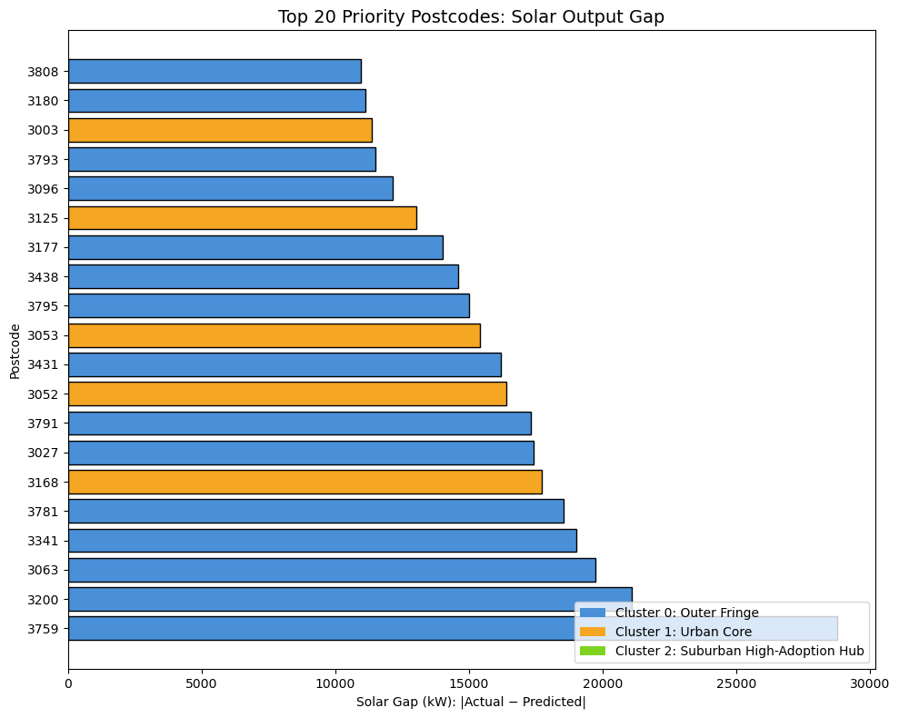

```python
# ---------- 5-5 Priority Postcodes Bar Chart ----------

import matplotlib.pyplot as plt
from matplotlib.patches import Patch

# Get the top 20 priority postcodes.
priority = df_final.sort_values('Residual').head(20).copy()

# Create postcode labels.
priority['Label'] = priority['Postcode'].astype(int).astype(str)

# Define colours by cluster.
cluster_colors = {0: '#4A90D9', 1: '#F5A623', 2: '#7ED321'}
colors = priority['Cluster'].map(cluster_colors)

# Sort so the largest gap appears at the TOP (ascending absolute value).
priority = priority.sort_values('Residual', ascending=True)

# Create horizontal bar chart using ABSOLUTE residual value.
fig, ax = plt.subplots(figsize=(10, 8))

ax.barh(priority['Label'], abs(priority['Residual']), color=colors, edgecolor='black')

ax.set_xlabel('Solar Gap (kW): |Actual − Predicted|')
ax.set_ylabel('Postcode')
ax.set_title('Top 20 Priority Postcodes: Solar Output Gap', fontsize=14)

legend_elements = [
    Patch(facecolor='#4A90D9', label='Cluster 0: Outer Fringe'),
    Patch(facecolor='#F5A623', label='Cluster 1: Urban Core'),
    Patch(facecolor='#7ED321', label='Cluster 2: Suburban High-Adoption Hub')
]
ax.legend(handles=legend_elements, loc='lower right')

plt.tight_layout()
plt.show()
```

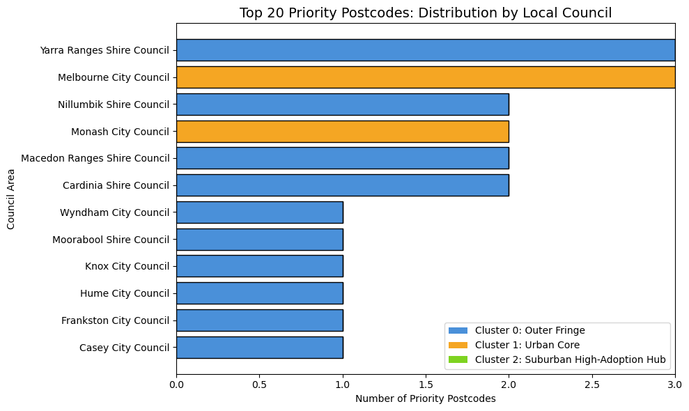

```python
# 5-5 Priority Postcodes by Council (Cluster-coloured) ----------

import matplotlib.pyplot as plt
import pandas as pd
from matplotlib.patches import Patch

# Get the top 20 priority postcodes.
priority = df_final.sort_values('Residual').head(20).copy()

# Count postcodes per council per cluster.
council_cluster = priority.groupby(['CouncilArea', 'Cluster']).size().unstack(fill_value=0)

# Sort by total count so the most frequent council is at the top.
council_cluster['Total'] = council_cluster.sum(axis=1)
council_cluster = council_cluster.sort_values('Total', ascending=True).drop(columns='Total')

# Define cluster colours and labels.
cluster_colors = {0: '#4A90D9', 1: '#F5A623', 2: '#7ED321'}
cluster_names = {0: 'Outer Fringe', 1: 'Urban Core', 2: 'Suburban High-Adoption Hub'}

# Create stacked horizontal bar chart.
fig, ax = plt.subplots(figsize=(10, 6))

left = pd.Series(0, index=council_cluster.index)
for cluster_id in council_cluster.columns:
    ax.barh(council_cluster.index, council_cluster[cluster_id],
            left=left, color=cluster_colors[cluster_id], edgecolor='black')
    left += council_cluster[cluster_id]

ax.set_xlabel('Number of Priority Postcodes')
ax.set_ylabel('Council Area')
ax.set_title('Top 20 Priority Postcodes: Distribution by Local Council', fontsize=14)

legend_elements = [
    Patch(facecolor='#4A90D9', label='Cluster 0: Outer Fringe'),
    Patch(facecolor='#F5A623', label='Cluster 1: Urban Core'),
    Patch(facecolor='#7ED321', label='Cluster 2: Suburban High-Adoption Hub')
]
ax.legend(handles=legend_elements, loc='lower right')

plt.tight_layout()
plt.show()
```

**Priority List Interpretation**

The 20 priority postcodes represent areas where ARENA can achieve the greatest impact by closing the gap between solar potential and actual adoption.

**Key findings from the priority list:**

- **5 postcodes are Urban Core (Cluster 1):**

Postcodes 3168, 3052, 3053, 3125, and 3003 sit in inner-to-middle suburban areas (2–17 km from CBD) with lower ownership rates (0.23–0.57). Their gaps range from 69–91%, suggesting that even within the urban core, pockets of housing with suitable roof space exist but remain underserved.

**Council-level patterns:**  
Among the 20 priority postcodes, two councils stand out with 3 postcodes each: **Yarra Ranges Shire Council** (all Outer Fringe) and **Melbourne City Council** (predominantly Urban Core). A further four councils — **Nillumbik Shire, Monash City, Macedon Ranges Shire, and Cardinia Shire** — each contain 2 priority postcodes. These six councils together account for 14 of the 20 priority postcodes, suggesting that ARENA can achieve broad impact by partnering with a small number of local councils rather than targeting postcodes individually.

These postcodes are recommended to ARENA as priority targets, with tailored strategies outlined in Section 5-6.

### **5-6 Recommendations**

Provide actionable strategies based on the findings.

Based on the clustering results, regression analysis, and solar gap findings, the following strategies are recommended for ARENA:

**1. Prioritise Outer Fringe postcodes (Cluster 0) with the largest solar gaps**

> 15 of the top 20 priority postcodes belong to the Outer Fringe. These areas have the most favourable housing conditions — large dwellings, high ownership rates — yet solar output is 63–96% below predictions. ARENA should consider mobile information sessions, installer referral programs, and subsidies targeting these low-density outer areas where access to solar services and awareness may be limited.  
> ARENA should prioritise partnerships with Yarra Ranges Shire Council (3 priority postcodes), Nillumbik Shire Council, Macedon Ranges Shire Council, and Cardinia Shire Council (2 each) to coordinate outreach efficiently across multiple postcodes within each council area.

**2. Address underperforming Urban Core postcodes (Cluster 1)**

> 5 priority postcodes sit within the inner-to-middle suburbs. Although the Urban Core generally faces structural barriers (apartments, renters), these specific postcodes contain pockets of suitable housing. ARENA should investigate localised campaigns in these areas, potentially partnering with local councils to identify owner-occupied houses within predominantly high-density zones.

**3. Use dwelling size and distance as key targeting criteria**

> Avg_Rooms (t = 4.03) and Avg_Distance (t = 2.37) are the two significant positive predictors of solar output. ARENA's future targeting models should prioritise postcodes with larger dwellings further from the CBD, as these characteristics indicate separate houses with suitable roof space.

**4. Reassess the role of ownership rate in targeting**

> Contrary to the initial hypothesis, ownership rate showed a negative association with total solar output at the postcode level. This counterintuitive finding suggests that while ownership enables individual adoption, it does not drive total postcode-level output — community scale matters more. ARENA should consider per-household adoption rates rather than aggregate output when evaluating ownership as a targeting criterion.

### **5-7 Limitations**

- **Data scope:**

The analysis covers only Melbourne postcodes; findings may not generalise to other Australian cities or regional areas.

- **Aggregation level:**

All features are aggregated at the postcode level, which may mask variation within a postcode (e.g. a postcode containing both apartments and houses).

- **Temporal mismatch:**

Housing transaction data, solar installation data, and Census data may cover slightly different time periods, which could introduce inconsistency.

- **Aggregate vs per-capita measure:**

Total_Output_kW measures aggregate solar output, not per-household adoption rate. This means postcodes with larger populations naturally have higher totals, which may obscure differences in individual adoption behaviour. A per-household metric could yield different conclusions, particularly for H3 (ownership rate).

- **Correlation not causation:**

Regression identifies associations, not causal relationships. The negative coefficient for ownership rate does not mean ownership discourages solar adoption — it reflects the confounding effect of community scale.

### **5-8 Future Work**

- Incorporate a per-household solar adoption rate (Total_Output_kW divided by Propertycount) as an alternative dependent variable to separate individual adoption behaviour from community scale effects.
- Incorporate additional socio-demographic variables such as household income and education level from Census data to enrich cluster profiles.
- Apply the analysis at a finer geographic level (e.g. SA2 or mesh block) to capture within-postcode variation.
- Include temporal trends to examine how solar adoption has changed over time across different area types.
- Extend the geographic scope beyond Melbourne to compare adoption patterns across Australian capital cities.